# R Notebook

For this analysis, we will be looking at an extended version of the Salary datas except this one will have around 397 observations. We will be looking at salary data of college professors in a midtown college to determine what features are statistically significant to our response, which is Salary. Once again we will be looking at sex, rank, discipline, years of service, and years since phd. We will be creating several models and then comparing each model’s prediction ability in the end.

```r
library(carData)
library(lmtest)
library(alr4)
library(rsample)
library(tidymodels)
library(caret)
library(dplyr)
library(yardstick)
head(Salaries)
```

[output not shown]

```r
summary(Salaries)
```

[output not shown]

[figure not shown]

```r
plot(Salaries)
```

[figure not shown]

```r
num_cols <- names(Salaries)[sapply(Salaries, is.numeric)]

par(mfrow=c(3,4), ask = FALSE)
for(col in num_cols){
  hist(Salaries[[col]], xlab = col, ylab = 'Frequency')
}
par(mfrow=c(1,1), ask = FALSE)
```

We see the data that we are working with and the distribution. We can see that Salary is a bit right skewed, however a simple transformation can alleviate this. We also see that we may have some sort of a correlation between Salary and years of service as well as salay and years since phd. Looking at the summary statistics tells us that the range of Salary may be a bit large and that we could possibly do a log transformation.

One thing we are going to look at once again, the difference in salaries between sexes. For our null hypothesis, we can say that there is no differences in the salaries between the sexes. Our alternative to this would be that males make more than females. We want to do a hypothesis test with both a t-test function as well as a permutation method.

```r
Salaries$yrs_service_plus <- Salaries$yrs.service + 0.1
Salaries$salary_inv_sqrt <- 1/sqrt(Salaries$salary)
Salaries$salary_pwr <- Salaries$salary^(-0.25)
Salaries$salary_log <- log(Salaries$salary)
str(Salaries)
```

```
'data.frame':   397 obs. of  10 variables:
 $ rank            : Factor w/ 3 levels "AsstProf","AssocProf",..: 3 3 1 3 3 2 3 3 3 3 ...
 $ discipline      : Factor w/ 2 levels "A","B": 2 2 2 2 2 2 2 2 2 2 ...
 $ yrs.since.phd   : int  19 20 4 45 40 6 30 45 21 18 ...
 $ yrs.service     : int  18 16 3 39 41 6 23 45 20 18 ...
 $ sex             : Factor w/ 2 levels "Female","Male": 2 2 2 2 2 2 2 2 2 1 ...
 $ salary          : int  139750 173200 79750 115000 141500 97000 175000 147765 119250 129000 ...
 $ yrs_service_plus: num  18.1 16.1 3.1 39.1 41.1 6.1 23.1 45.1 20.1 18.1 ...
 $ salary_inv_sqrt : num  0.00268 0.0024 0.00354 0.00295 0.00266 ...
 $ salary_pwr      : num  0.0517 0.049 0.0595 0.0543 0.0516 ...
 $ salary_log      : num  11.8 12.1 11.3 11.7 11.9 ...
```

```r
means <- tapply(Salaries$salary, Salaries$sex, mean)
original_difference <- means[2] - means[1]
print(means)
```

```
  Female     Male
101002.4 115090.4
```

```r
print(paste("Original Difference:", original_difference))
```

```
[1] "Original Difference: 14088.0087380032"
```

```r
t.test(x = Salaries$salary[Salaries$sex == 'Male'], y = Salaries$salary[Salaries$sex == 'Female'], alternative = 'greater')
```

```
    Welch Two Sample t-test

data:  Salaries$salary[Salaries$sex == "Male"] and Salaries$salary[Salaries$sex == "Female"]
t = 3.1615, df = 50.122, p-value = 0.001332
alternative hypothesis: true difference in means is greater than 0
95 percent confidence interval:
 6620.263      Inf
sample estimates:
mean of x mean of y
 115090.4  101002.4
```

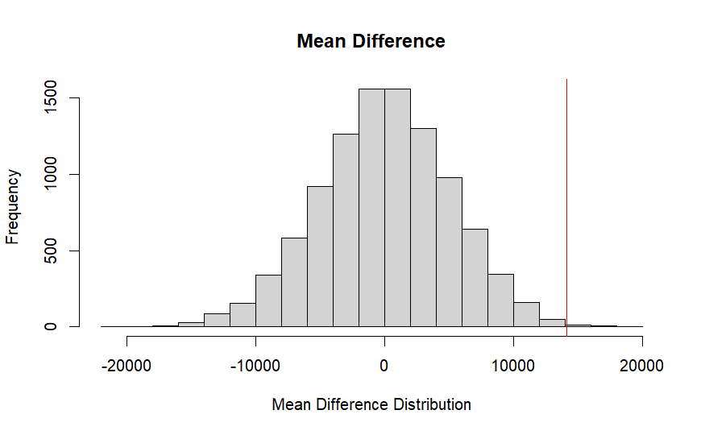

```r
boots <- NULL
for( i in 1:10000){
  new_salary <- sample(Salaries$salary, dim(Salaries)[1], replace = FALSE)
  salary_df <- data.frame(sex = Salaries$sex, salary = new_salary)
  new_means <- tapply(salary_df$salary, salary_df$sex, mean)
  differences <- new_means[2] - new_means[1]
  boots <- c(boots, differences)
}

hist(boots, breaks = 20, xlab = 'Mean Difference Distribution', ylab = 'Frequency', main = 'Mean Difference')
abline(v = original_difference, col = 'red')
```

```r
pvalue <- original_difference < boots
print(sum(pvalue)/10000)
```

```
[1] 0.0018
```

Both tests conclude that we reject the null hypothesis that male and female make the same amount given that the null distribution was true. However, we know that statistical modeling entails much more than just hypothesis testing, especially when we have more features to take account of any variation of data. So, we will begin by building our preliminary model.

```r
salaryfit <- lm(salary~sex+rank+discipline+yrs.service+yrs.since.phd, data = Salaries)
print(summary(salaryfit))
```

```
Call:
lm(formula = salary ~ sex + rank + discipline + yrs.service +
    yrs.since.phd, data = Salaries)

Residuals:
   Min     1Q Median     3Q    Max
-65248 -13211  -1775  10384  99592

Coefficients:
              Estimate Std. Error t value Pr(>|t|)
(Intercept)    65955.2     4588.6  14.374  < 2e-16 ***
sexMale         4783.5     3858.7   1.240  0.21584
rankAssocProf  12907.6     4145.3   3.114  0.00198 **
rankProf       45066.0     4237.5  10.635  < 2e-16 ***
disciplineB    14417.6     2342.9   6.154 1.88e-09 ***
yrs.service     -489.5      211.9  -2.310  0.02143 *
yrs.since.phd    535.1      241.0   2.220  0.02698 *
---
Signif. codes:  0 ‘***’ 0.001 ‘**’ 0.01 ‘*’ 0.05 ‘.’ 0.1 ‘ ’ 1

Residual standard error: 22540 on 390 degrees of freedom
Multiple R-squared:  0.4547,    Adjusted R-squared:  0.4463
F-statistic:  54.2 on 6 and 390 DF,  p-value: < 2.2e-16
```

```r
Anova(salaryfit, type = 'II')
```

```
Anova Table (Type II tests)

Response: salary
                  Sum Sq  Df F value    Pr(>F)
sex           7.8068e+08   1  1.5368   0.21584
rank          6.9508e+10   2 68.4143 < 2.2e-16 ***
discipline    1.9237e+10   1 37.8695 1.878e-09 ***
yrs.service   2.7100e+09   1  5.3348   0.02143 *
yrs.since.phd 2.5041e+09   1  4.9293   0.02698 *
Residuals     1.9812e+11 390
---
Signif. codes:  0 ‘***’ 0.001 ‘**’ 0.01 ‘*’ 0.05 ‘.’ 0.1 ‘ ’ 1
```

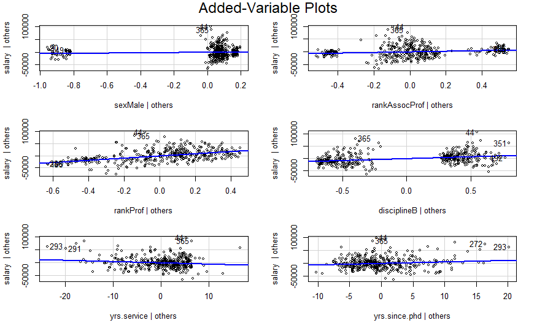

```r
avPlots(salaryfit)
```

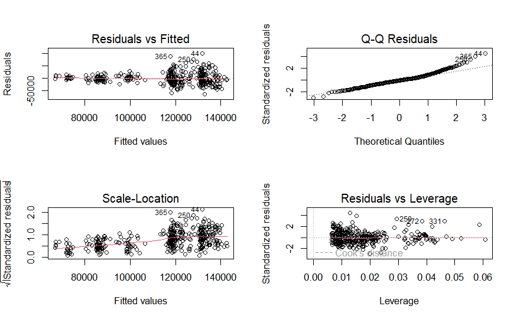

```r
par(mfrow = c(2,2), ask = FALSE)
plot(salaryfit)
```

```
              Test stat Pr(>|Test stat|)
sex
rank
discipline
yrs.service     -1.0707          0.28498
yrs.since.phd   -2.2529          0.02482 *
Tukey test      -0.0736          0.94131
---
Signif. codes:  0 ‘***’ 0.001 ‘**’ 0.01 ‘*’ 0.05 ‘.’ 0.1 ‘ ’ 1
```

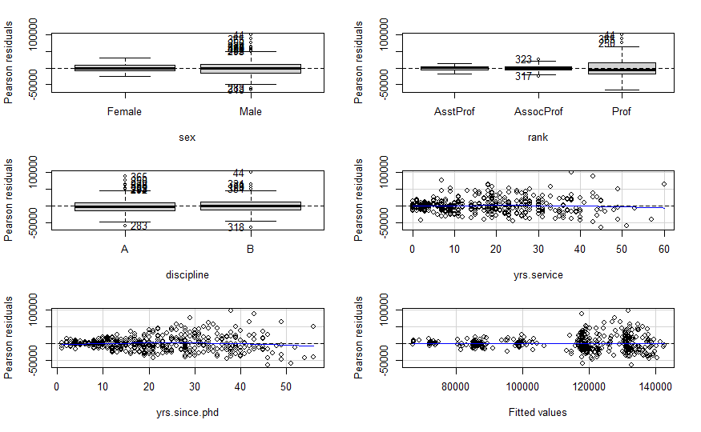

```r
residualPlots(salaryfit)
```

```r
print(resettest(salaryfit, power = 2:3, type = 'regressor'))
```

```
    RESET test

data:  salaryfit
RESET = 4.3836, df1 = 4, df2 = 386, p-value = 0.001774
```

```r
print(resettest(salaryfit, power = 2:3, type = 'fitted'))
```

```
    RESET test

data:  salaryfit
RESET = 3.6837, df1 = 2, df2 = 388, p-value = 0.02601
```

```r
ncvTest(salaryfit)
```

```
Non-constant Variance Score Test
Variance formula: ~ fitted.values
Chisquare = 66.51281, Df = 1, p = 3.4763e-16
```

```r
bptest(salaryfit)
```

```
    studentized Breusch-Pagan test

data:  salaryfit
BP = 65.055, df = 6, p-value = 4.205e-12
```

```r
vif(salaryfit)
```

```
                  GVIF Df GVIF^(1/(2*Df))
sex           1.030805  1        1.015285
rank          2.013193  2        1.191163
discipline    1.064105  1        1.031555
yrs.service   5.923038  1        2.433729
yrs.since.phd 7.518936  1        2.742068
```

```r
outlierTest(salaryfit)
```

|  | rstudent | unadjusted p-value | Bonferroni p |
| --- | --- | --- | --- |
| 44 | 4.558843 | 6.8992e-06 | 0.002739 |
| 365 | 3.997249 | 7.6676e-05 | 0.030440 |

```r
infl <- data.frame(
  hat = hatvalues(salaryfit),
  cooks = cooks.distance(salaryfit),
  rstandard = rstandard(salaryfit),
  rstudent = rstudent(salaryfit)
)

infl <- infl[order(infl$cooks, decreasing = TRUE),]
print(head(infl))
```

|  | hat | cooks | rstandard | rstudent |
| --- | --- | --- | --- | --- |
| 331 | 0.04645874 | 0.06105387 | 2.961704 | 2.991740 |
| 250 | 0.02941386 | 0.05085794 | 3.427437 | 3.475788 |
| 272 | 0.03834507 | 0.04977339 | 2.955987 | 2.985833 |
| 293 | 0.05873675 | 0.04951260 | 2.356717 | 2.370635 |
| 44 | 0.01287168 | 0.03684541 | 4.447439 | 4.558843 |
| 365 | 0.01518710 | 0.03389837 | 3.922634 | 3.997249 |

We can try to do a multivariate power transformation to see if this will fix any of our issues. We will also add in interactions with all the variables to weed out what is important and what is not.

```r
summary(powerTransform(cbind(yrs_service_plus, yrs.since.phd, salary)~1, Salaries))
```

```
bcPower Transformations to Multinormality
                 Est Power Rounded Pwr Wald Lwr Bnd Wald Upr Bnd
yrs_service_plus    0.5238         0.5       0.4595       0.5881
yrs.since.phd       0.5854         0.5       0.4916       0.6792
salary             -0.2584         0.0      -0.5952       0.0784

Likelihood ratio test that transformation parameters are equal to 0
 (all log transformations)
```

|  | LRT | df | pval |
| --- | --- | --- | --- |
| LR test, lambda = (0 0 0) | 430.5144 | 3 | < 2.22e-16 |

```
Likelihood ratio test that no transformations are needed
```

|  | LRT | df | pval |
| --- | --- | --- | --- |
| LR test, lambda = (1 1 1) | 211.4055 | 3 | < 2.22e-16 |

We have several transformations for our continuous covariates that may deem to be un-interpretable, however we will try to and run these first and see what our diagnostics look like. We can then substitute these for transformations that are a bit more interpretable for any potential audience.

```r
salarypwr <- lm(I(salary^-0.25)~rank*discipline*sex*I(yrs_service_plus^0.52)*I(yrs.since.phd^0.59), data = Salaries)
print(summary(salarypwr))
```

```
Call:
lm(formula = I(salary^-0.25) ~ rank * discipline * sex * I(yrs_service_plus^0.52) *
    I(yrs.since.phd^0.59), data = Salaries)

Residuals:
       Min         1Q     Median         3Q        Max
-0.0088517 -0.0011497 -0.0000896  0.0012177  0.0098336

Coefficients:
                                                                                  Estimate Std. Error t value
(Intercept)                                                                       0.068256   0.008745   7.805
rankAssocProf                                                                    -0.158932   0.201317  -0.789
rankProf                                                                         -0.009877   0.011938  -0.827
disciplineB                                                                      -0.029336   0.027137  -1.081
sexMale                                                                          -0.012596   0.011041  -1.141
I(yrs_service_plus^0.52)                                                         -0.002428   0.006255  -0.388
I(yrs.since.phd^0.59)                                                            -0.004897   0.004908  -0.998
rankAssocProf:disciplineB                                                         0.196726   0.228424   0.861
rankProf:disciplineB                                                              0.119981   0.062828   1.910
rankAssocProf:sexMale                                                             0.158833   0.201502   0.788
rankProf:sexMale                                                                  0.028711   0.014144   2.030
disciplineB:sexMale                                                               0.032721   0.028064   1.166
rankAssocProf:I(yrs_service_plus^0.52)                                            0.052117   0.069519   0.750
rankProf:I(yrs_service_plus^0.52)                                                 0.004677   0.006580   0.711
disciplineB:I(yrs_service_plus^0.52)                                              0.011941   0.015410   0.775
sexMale:I(yrs_service_plus^0.52)                                                  0.006966   0.007727   0.901
rankAssocProf:I(yrs.since.phd^0.59)                                               0.027573   0.029721   0.928
rankProf:I(yrs.since.phd^0.59)                                                    0.004096   0.005153   0.795
disciplineB:I(yrs.since.phd^0.59)                                                 0.013295   0.010787   1.232
sexMale:I(yrs.since.phd^0.59)                                                     0.006775   0.005775   1.173
I(yrs_service_plus^0.52):I(yrs.since.phd^0.59)                                    0.002039   0.002509   0.813
rankAssocProf:disciplineB:sexMale                                                -0.198989   0.228640  -0.870
rankProf:disciplineB:sexMale                                                     -0.146921   0.063427  -2.316
rankAssocProf:disciplineB:I(yrs_service_plus^0.52)                               -0.062762   0.080872  -0.776
rankProf:disciplineB:I(yrs_service_plus^0.52)                                    -0.032181   0.019172  -1.679
rankAssocProf:sexMale:I(yrs_service_plus^0.52)                                   -0.054443   0.069679  -0.781
rankProf:sexMale:I(yrs_service_plus^0.52)                                        -0.012487   0.008030  -1.555
disciplineB:sexMale:I(yrs_service_plus^0.52)                                     -0.017264   0.016193  -1.066
rankAssocProf:disciplineB:I(yrs.since.phd^0.59)                                  -0.037727   0.039153  -0.964
rankProf:disciplineB:I(yrs.since.phd^0.59)                                       -0.028326   0.014413  -1.965
```

[output cut: 58 more lines]

```
rankAssocProf:disciplineB:sexMale:I(yrs.since.phd^0.59)                            0.3140
rankProf:disciplineB:sexMale:I(yrs.since.phd^0.59)                                 0.0219 *
rankAssocProf:disciplineB:I(yrs_service_plus^0.52):I(yrs.since.phd^0.59)           0.3800
rankProf:disciplineB:I(yrs_service_plus^0.52):I(yrs.since.phd^0.59)                0.1197
rankAssocProf:sexMale:I(yrs_service_plus^0.52):I(yrs.since.phd^0.59)               0.3003
rankProf:sexMale:I(yrs_service_plus^0.52):I(yrs.since.phd^0.59)                    0.1492
disciplineB:sexMale:I(yrs_service_plus^0.52):I(yrs.since.phd^0.59)                 0.1899
rankAssocProf:disciplineB:sexMale:I(yrs_service_plus^0.52):I(yrs.since.phd^0.59)   0.3298
rankProf:disciplineB:sexMale:I(yrs_service_plus^0.52):I(yrs.since.phd^0.59)        0.0640 .
---
Signif. codes:  0 ‘***’ 0.001 ‘**’ 0.01 ‘*’ 0.05 ‘.’ 0.1 ‘ ’ 1

Residual standard error: 0.002334 on 349 degrees of freedom
Multiple R-squared:  0.6223,    Adjusted R-squared:  0.5714
F-statistic: 12.23 on 47 and 349 DF,  p-value: < 2.2e-16
```

```r
Anova(salarypwr, type = 'II')
```

```
Anova Table (Type II tests)

Response: I(salary^-0.25)
                                                                       Sum Sq  Df F value    Pr(>F)
rank                                                               0.00046724   2 42.8979 < 2.2e-16 ***
discipline                                                         0.00028409   1 52.1657 3.223e-12 ***
sex                                                                0.00000925   1  1.6984 0.1933572
I(yrs_service_plus^0.52)                                           0.00002476   1  4.5464 0.0336863 *
I(yrs.since.phd^0.59)                                              0.00001888   1  3.4676 0.0634214 .
rank:discipline                                                    0.00002059   2  1.8902 0.1525821
rank:sex                                                           0.00000241   2  0.2216 0.8013871
discipline:sex                                                     0.00001403   1  2.5757 0.1094228
rank:I(yrs_service_plus^0.52)                                      0.00001498   2  1.3755 0.2540701
discipline:I(yrs_service_plus^0.52)                                0.00006092   1 11.1871 0.0009132 ***
sex:I(yrs_service_plus^0.52)                                       0.00000001   1  0.0013 0.9715658
rank:I(yrs.since.phd^0.59)                                         0.00000713   2  0.6543 0.5204660
discipline:I(yrs.since.phd^0.59)                                   0.00004098   1  7.5257 0.0063963 **
sex:I(yrs.since.phd^0.59)                                          0.00000367   1  0.6732 0.4124938
I(yrs_service_plus^0.52):I(yrs.since.phd^0.59)                     0.00006378   1 11.7117 0.0006948 ***
rank:discipline:sex                                                0.00000362   2  0.3324 0.7174163
rank:discipline:I(yrs_service_plus^0.52)                           0.00000839   2  0.7703 0.4636771
rank:sex:I(yrs_service_plus^0.52)                                  0.00000192   2  0.1762 0.8385183
discipline:sex:I(yrs_service_plus^0.52)                            0.00000389   1  0.7151 0.3983276
rank:discipline:I(yrs.since.phd^0.59)                              0.00000198   2  0.1814 0.8341534
rank:sex:I(yrs.since.phd^0.59)                                     0.00000082   2  0.0752 0.9275789
discipline:sex:I(yrs.since.phd^0.59)                               0.00000003   1  0.0064 0.9361624
rank:I(yrs_service_plus^0.52):I(yrs.since.phd^0.59)                0.00001652   2  1.5165 0.2209167
discipline:I(yrs_service_plus^0.52):I(yrs.since.phd^0.59)          0.00006830   1 12.5415 0.0004520 ***
sex:I(yrs_service_plus^0.52):I(yrs.since.phd^0.59)                 0.00002601   1  4.7763 0.0295175 *
rank:discipline:sex:I(yrs_service_plus^0.52)                       0.00000622   2  0.5707 0.5656450
rank:discipline:sex:I(yrs.since.phd^0.59)                          0.00001429   2  1.3116 0.2707134
rank:discipline:I(yrs_service_plus^0.52):I(yrs.since.phd^0.59)     0.00004101   2  3.7654 0.0241040 *
rank:sex:I(yrs_service_plus^0.52):I(yrs.since.phd^0.59)            0.00000441   2  0.4051 0.6672562
discipline:sex:I(yrs_service_plus^0.52):I(yrs.since.phd^0.59)      0.00001353   1  2.4837 0.1159342
rank:discipline:sex:I(yrs_service_plus^0.52):I(yrs.since.phd^0.59) 0.00001924   2  1.7665 0.1724523
Residuals                                                          0.00190063 349
---
Signif. codes:  0 ‘***’ 0.001 ‘**’ 0.01 ‘*’ 0.05 ‘.’ 0.1 ‘ ’ 1
```

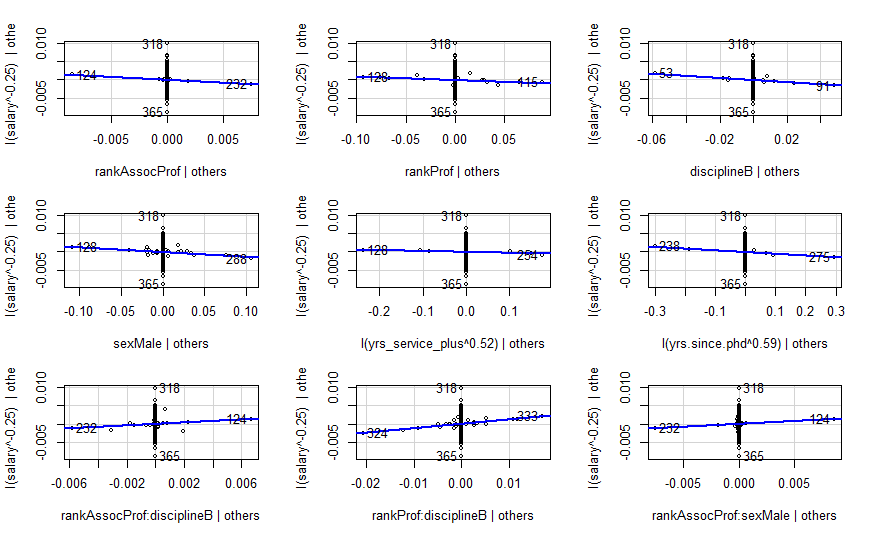

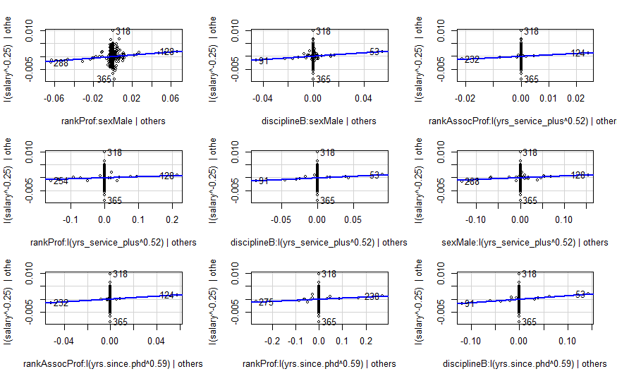

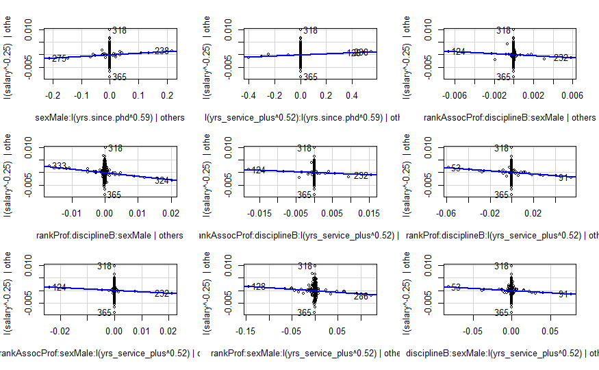

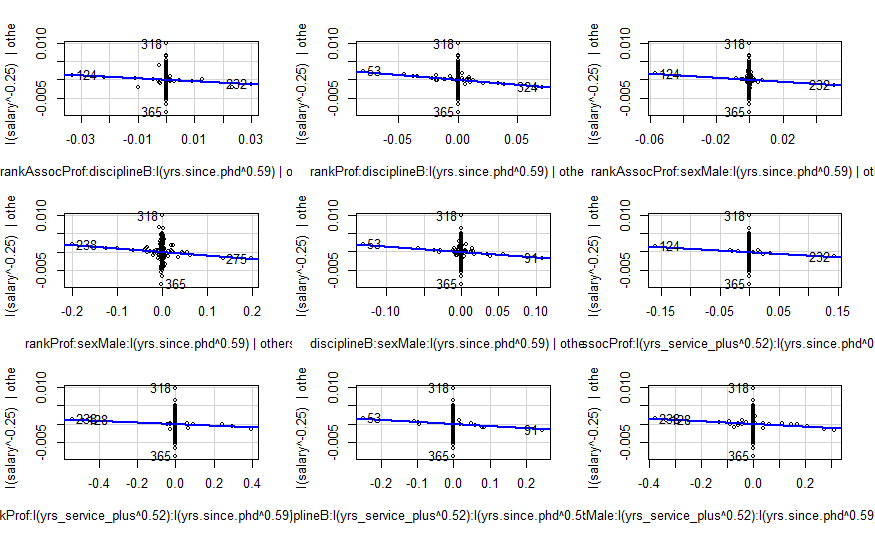

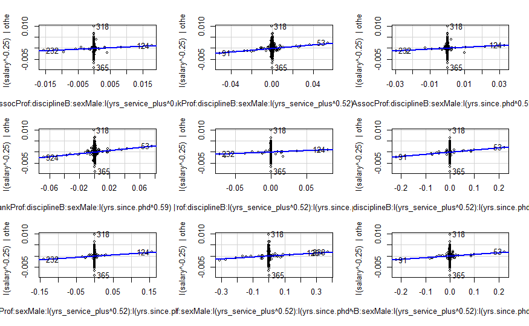

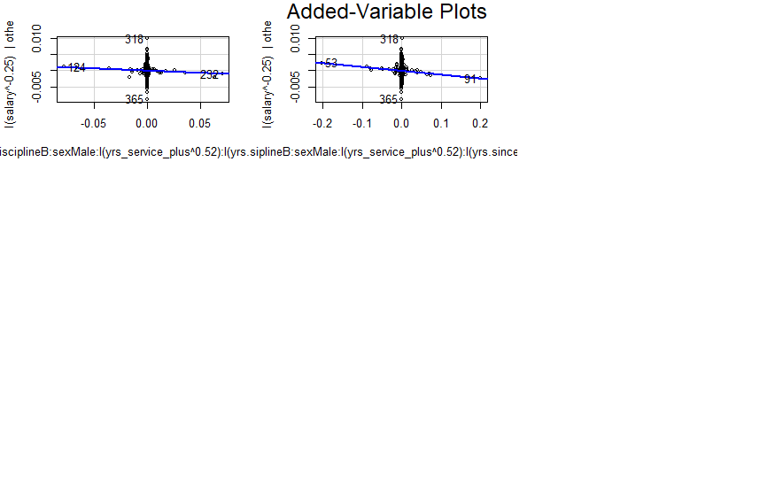

```r
avPlots(salarypwr, ask = FALSE)
```

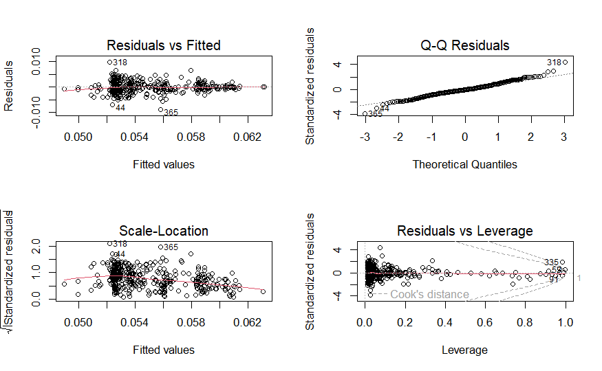

```r
par(mfrow = c(2,2), ask = FALSE)
plot(salarypwr)
```

```
                         Test stat Pr(>|Test stat|)
rank
discipline
sex
I(yrs_service_plus^0.52)   -2.0612          0.04002 *
I(yrs.since.phd^0.59)       1.0119          0.31230
Tukey test                 -1.0785          0.28080
---
Signif. codes:  0 ‘***’ 0.001 ‘**’ 0.01 ‘*’ 0.05 ‘.’ 0.1 ‘ ’ 1
```

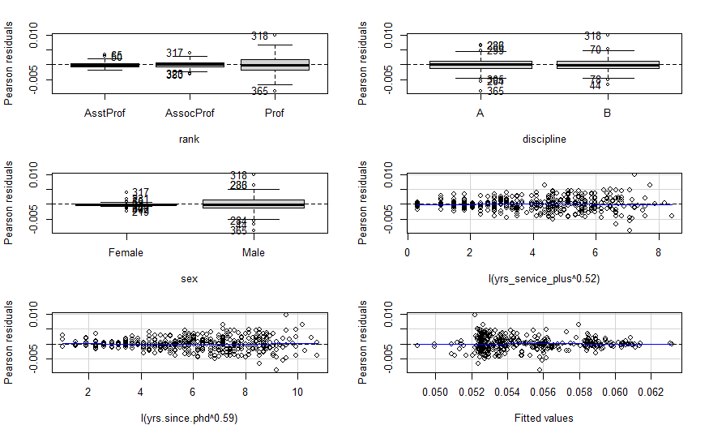

```r
residualPlots(salarypwr)
```

```r
print(resettest(salarypwr, power = 2:3, type = 'regressor'))
```

```
    RESET test

data:  salarypwr
RESET = 1.3327, df1 = 4, df2 = 345, p-value = 0.2574
```

```r
print(resettest(salarypwr, power = 2:3, type = 'fitted'))
```

```
    RESET test

data:  salarypwr
RESET = 1.8507, df1 = 2, df2 = 347, p-value = 0.1587
```

```r
ncvTest(salarypwr)
```

```
Non-constant Variance Score Test
Variance formula: ~ fitted.values
Chisquare = 34.43288, Df = 1, p = 4.4121e-09
```

```r
bptest(salarypwr)
```

```
    studentized Breusch-Pagan test

data:  salarypwr
BP = 68.835, df = 47, p-value = 0.02059
```

```r
vif(salarypwr)
```

```
                                                                           GVIF Df GVIF^(1/(2*Df))
rank                                                               5.589247e+08  2       153.75822
discipline                                                         1.331703e+04  1       115.39943
sex                                                                7.871696e+02  1        28.05654
I(yrs_service_plus^0.52)                                           9.522659e+03  1        97.58411
I(yrs.since.phd^0.59)                                              8.891124e+03  1        94.29276
rank:discipline                                                    2.004831e+10  2       376.28721
rank:sex                                                           8.760215e+08  2       172.03970
discipline:sex                                                     1.434890e+04  1       119.78690
rank:I(yrs_service_plus^0.52)                                      1.007493e+10  2       316.81849
discipline:I(yrs_service_plus^0.52)                                9.232803e+04  1       303.85527
sex:I(yrs_service_plus^0.52)                                       1.995183e+04  1       141.25095
rank:I(yrs.since.phd^0.59)                                         3.843477e+09  2       248.98952
discipline:I(yrs.since.phd^0.59)                                   8.605340e+04  1       293.34860
sex:I(yrs.since.phd^0.59)                                          1.912715e+04  1       138.30095
I(yrs_service_plus^0.52):I(yrs.since.phd^0.59)                     1.795987e+05  1       423.79088
rank:discipline:sex                                                1.709636e+10  2       361.59792
rank:discipline:I(yrs_service_plus^0.52)                           7.209444e+10  2       518.17379
rank:sex:I(yrs_service_plus^0.52)                                  1.537733e+10  2       352.14396
discipline:sex:I(yrs_service_plus^0.52)                            1.023549e+05  1       319.92948
rank:discipline:I(yrs.since.phd^0.59)                              3.367273e+10  2       428.37054
rank:sex:I(yrs.since.phd^0.59)                                     5.510564e+09  2       272.45765
discipline:sex:I(yrs.since.phd^0.59)                               9.457638e+04  1       307.53274
rank:I(yrs_service_plus^0.52):I(yrs.since.phd^0.59)                1.207181e+11  2       589.44480
discipline:I(yrs_service_plus^0.52):I(yrs.since.phd^0.59)          7.676809e+05  1       876.17404
sex:I(yrs_service_plus^0.52):I(yrs.since.phd^0.59)                 2.944362e+05  1       542.61978
rank:discipline:sex:I(yrs_service_plus^0.52)                       6.744356e+10  2       509.60669
rank:discipline:sex:I(yrs.since.phd^0.59)                          3.035053e+10  2       417.38956
rank:discipline:I(yrs_service_plus^0.52):I(yrs.since.phd^0.59)     4.370335e+11  2       813.07141
rank:sex:I(yrs_service_plus^0.52):I(yrs.since.phd^0.59)            1.742390e+11  2       646.08006
discipline:sex:I(yrs_service_plus^0.52):I(yrs.since.phd^0.59)      8.574040e+05  1       925.96111
rank:discipline:sex:I(yrs_service_plus^0.52):I(yrs.since.phd^0.59) 4.477820e+11  2       818.02517
```

```r
outlierTest(salarypwr)
```

|  | rstudent | unadjusted p-value | Bonferroni p |
| --- | --- | --- | --- |
| 318 | 4.498941 | 9.3217e-06 | 0.0036634 |
| 365 | -3.925572 | 1.0431e-04 | 0.0409930 |

```r
inf <- data.frame(
  hat = hatvalues(salarypwr),
  cooks = cooks.distance(salarypwr),
  rstandard = rstandard(salarypwr),
  rstudent = rstudent(salarypwr)
)

infl <- infl[order(infl$cooks, decreasing = TRUE),]
print(head(infl))
```

|  | hat | cooks | rstandard | rstudent |
| --- | --- | --- | --- | --- |
| 331 | 0.04645874 | 0.06105387 | 2.961704 | 2.991740 |
| 250 | 0.02941386 | 0.05085794 | 3.427437 | 3.475788 |
| 272 | 0.03834507 | 0.04977339 | 2.955987 | 2.985833 |
| 293 | 0.05873675 | 0.04951260 | 2.356717 | 2.370635 |
| 44 | 0.01287168 | 0.03684541 | 4.447439 | 4.558843 |
| 365 | 0.01518710 | 0.03389837 | 3.922634 | 3.997249 |

We see that our diagnostics look a lot better and that we do meet linearity when we test against the fitted values using the linear reset test. We also see that our variance is still heteroscedastic, but it is far more constant than before. Of course we see some multi-collinearity which comes with interactions, but we also see many variables that are not significant. We can look to see about dropping some of these variables and comparing our sub-model with our current model to see if the more complex one is even necessary. We will eliminate sex, ironically, as that seems to be insignificant all across the board, both the main effects and it’s interactions. The only instance where sex seems to matter is through it’s non-linear relationship with years of service and years since phD. We will remove all instances of sex, entirely, from the model.

```r
salarypwr_mod <- lm(I(salary^-0.25)~rank+discipline+I(yrs_service_plus^0.52)+I(yrs.since.phd^0.59)+discipline*I(yrs_service_plus^0.52)+discipline*I(yrs.since.phd^0.59)+discipline*I(yrs_service_plus^0.52)*I(yrs.since.phd^0.59)+rank*discipline*I(yrs_service_plus^0.52)*I(yrs.since.phd^0.59), data = Salaries)
print(summary(salarypwr_mod))
```

```
Call:
lm(formula = I(salary^-0.25) ~ rank + discipline + I(yrs_service_plus^0.52) +
    I(yrs.since.phd^0.59) + discipline * I(yrs_service_plus^0.52) +
    discipline * I(yrs.since.phd^0.59) + discipline * I(yrs_service_plus^0.52) *
    I(yrs.since.phd^0.59) + rank * discipline * I(yrs_service_plus^0.52) *
    I(yrs.since.phd^0.59), data = Salaries)

Residuals:
       Min         1Q     Median         3Q        Max
-0.0087647 -0.0013337 -0.0000821  0.0013730  0.0098419

Coefficients:
                                                                           Estimate Std. Error t value Pr(>|t|)
(Intercept)                                                               5.979e-02  5.063e-03  11.810  < 2e-16 ***
rankAssocProf                                                            -5.925e-03  7.092e-03  -0.835  0.40398
rankProf                                                                  1.225e-02  5.893e-03   2.078  0.03837 *
disciplineB                                                              -1.064e-03  5.550e-03  -0.192  0.84808
I(yrs_service_plus^0.52)                                                  2.198e-03  3.481e-03   0.632  0.52809
I(yrs.since.phd^0.59)                                                    -7.574e-05  2.400e-03  -0.032  0.97484
disciplineB:I(yrs_service_plus^0.52)                                     -2.709e-03  3.885e-03  -0.697  0.48604
disciplineB:I(yrs.since.phd^0.59)                                         4.723e-04  2.580e-03   0.183  0.85489
I(yrs_service_plus^0.52):I(yrs.since.phd^0.59)                           -4.964e-04  1.337e-03  -0.371  0.71074
rankAssocProf:disciplineB                                                 3.837e-03  8.553e-03   0.449  0.65395
rankProf:disciplineB                                                     -1.922e-02  7.205e-03  -2.667  0.00798 **
rankAssocProf:I(yrs_service_plus^0.52)                                    5.336e-04  3.680e-03   0.145  0.88479
rankProf:I(yrs_service_plus^0.52)                                        -4.954e-03  3.541e-03  -1.399  0.16268
rankAssocProf:I(yrs.since.phd^0.59)                                      -1.002e-04  2.725e-03  -0.037  0.97069
rankProf:I(yrs.since.phd^0.59)                                           -3.099e-03  2.446e-03  -1.267  0.20603
disciplineB:I(yrs_service_plus^0.52):I(yrs.since.phd^0.59)                4.339e-04  1.496e-03   0.290  0.77193
rankAssocProf:disciplineB:I(yrs_service_plus^0.52)                        1.468e-05  4.235e-03   0.003  0.99724
rankProf:disciplineB:I(yrs_service_plus^0.52)                             5.512e-03  4.003e-03   1.377  0.16940
rankAssocProf:disciplineB:I(yrs.since.phd^0.59)                          -5.884e-04  3.000e-03  -0.196  0.84460
rankProf:disciplineB:I(yrs.since.phd^0.59)                                2.988e-03  2.684e-03   1.113  0.26637
rankAssocProf:I(yrs_service_plus^0.52):I(yrs.since.phd^0.59)              3.244e-04  1.349e-03   0.240  0.81015
rankProf:I(yrs_service_plus^0.52):I(yrs.since.phd^0.59)                   9.939e-04  1.340e-03   0.742  0.45870
rankAssocProf:disciplineB:I(yrs_service_plus^0.52):I(yrs.since.phd^0.59) -2.178e-04  1.515e-03  -0.144  0.88579
rankProf:disciplineB:I(yrs_service_plus^0.52):I(yrs.since.phd^0.59)      -9.697e-04  1.502e-03  -0.646  0.51880
---
Signif. codes:  0 ‘***’ 0.001 ‘**’ 0.01 ‘*’ 0.05 ‘.’ 0.1 ‘ ’ 1

Residual standard error: 0.002321 on 373 degrees of freedom
Multiple R-squared:  0.6006,    Adjusted R-squared:  0.576
F-statistic: 24.39 on 23 and 373 DF,  p-value: < 2.2e-16
```

```r
Anova(salarypwr_mod, type = 'III')
```

```
Anova Table (Type III tests)

Response: I(salary^-0.25)
                                                                   Sum Sq  Df  F value    Pr(>F)
(Intercept)                                                    0.00075145   1 139.4694 < 2.2e-16 ***
rank                                                           0.00006173   2   5.7288 0.0035436 **
discipline                                                     0.00000020   1   0.0368 0.8480776
I(yrs_service_plus^0.52)                                       0.00000215   1   0.3988 0.5280918
I(yrs.since.phd^0.59)                                          0.00000001   1   0.0010 0.9748410
discipline:I(yrs_service_plus^0.52)                            0.00000262   1   0.4863 0.4860369
discipline:I(yrs.since.phd^0.59)                               0.00000018   1   0.0335 0.8548870
I(yrs_service_plus^0.52):I(yrs.since.phd^0.59)                 0.00000074   1   0.1377 0.7107412
rank:discipline                                                0.00006115   2   5.6743 0.0037362 **
rank:I(yrs_service_plus^0.52)                                  0.00009346   2   8.6732 0.0002081 ***
rank:I(yrs.since.phd^0.59)                                     0.00003243   2   3.0094 0.0505228 .
discipline:I(yrs_service_plus^0.52):I(yrs.since.phd^0.59)      0.00000045   1   0.0841 0.7719255
rank:discipline:I(yrs_service_plus^0.52)                       0.00004898   2   4.5456 0.0112081 *
rank:discipline:I(yrs.since.phd^0.59)                          0.00002793   2   2.5918 0.0762363 .
rank:I(yrs_service_plus^0.52):I(yrs.since.phd^0.59)            0.00006511   2   6.0422 0.0026153 **
rank:discipline:I(yrs_service_plus^0.52):I(yrs.since.phd^0.59) 0.00004217   2   3.9131 0.0208039 *
Residuals                                                      0.00200969 373
---
Signif. codes:  0 ‘***’ 0.001 ‘**’ 0.01 ‘*’ 0.05 ‘.’ 0.1 ‘ ’ 1
```

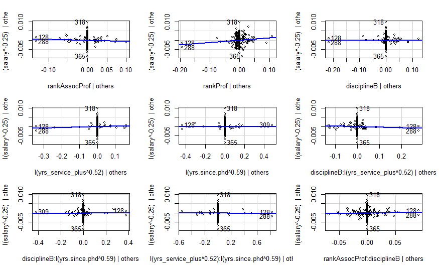

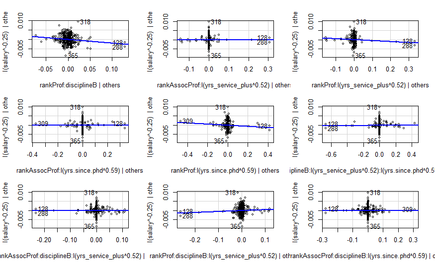

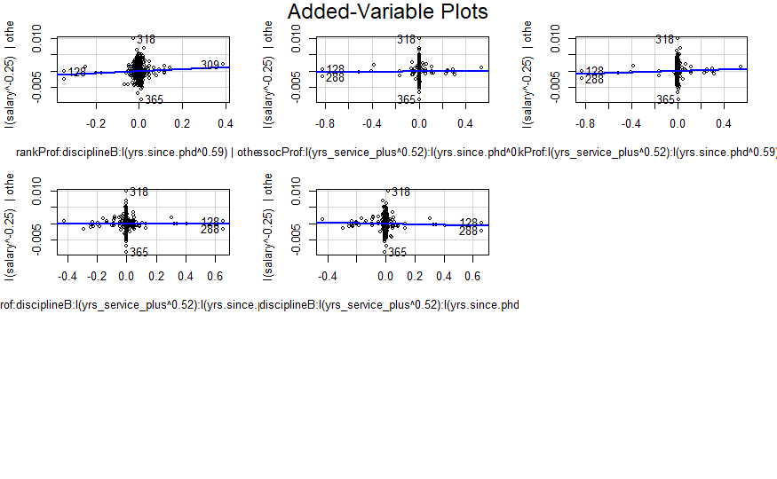

```r
avPlots(salarypwr_mod, ask = FALSE)
```

```r
print(anova(salarypwr_mod, salarypwr))
```

```
Analysis of Variance Table

Model 1: I(salary^-0.25) ~ rank + discipline + I(yrs_service_plus^0.52) +
    I(yrs.since.phd^0.59) + discipline * I(yrs_service_plus^0.52) +
    discipline * I(yrs.since.phd^0.59) + discipline * I(yrs_service_plus^0.52) *
    I(yrs.since.phd^0.59) + rank * discipline * I(yrs_service_plus^0.52) *
    I(yrs.since.phd^0.59)
Model 2: I(salary^-0.25) ~ rank * discipline * sex * I(yrs_service_plus^0.52) *
    I(yrs.since.phd^0.59)
  Res.Df       RSS Df  Sum of Sq      F Pr(>F)
1    373 0.0020097
2    349 0.0019006 24 0.00010905 0.8344 0.6923
```

We see that our ANOVA concludes that there is no difference between our two models so we will go with the smaller one and do further analysis and diagnostics to make sure that assumptions are met even better or worse. Not only that, the simpler model seems to have a better adjusted R-2.

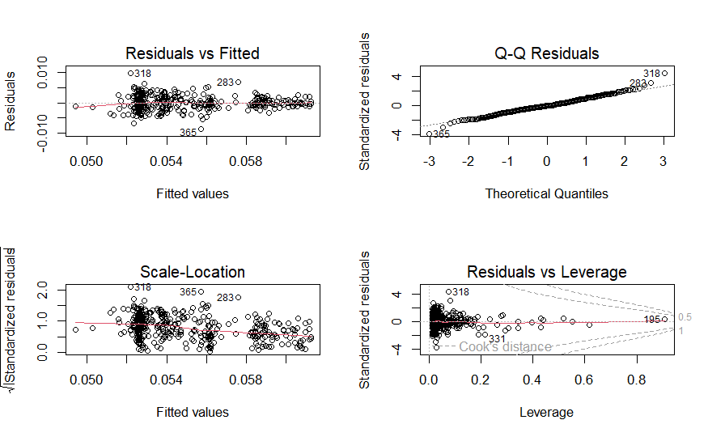

```r
par(mfrow=c(2,2))
plot(salarypwr_mod)
```

```
                         Test stat Pr(>|Test stat|)
rank
discipline
I(yrs_service_plus^0.52)   -2.3205          0.02085 *
I(yrs.since.phd^0.59)       1.2037          0.22947
Tukey test                 -1.0745          0.28261
---
Signif. codes:  0 ‘***’ 0.001 ‘**’ 0.01 ‘*’ 0.05 ‘.’ 0.1 ‘ ’ 1
```

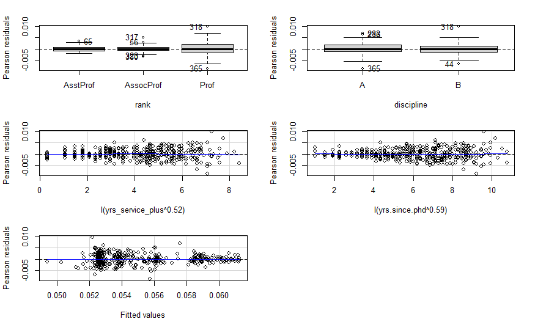

```r
residualPlots(salarypwr_mod, ask = FALSE)
```

```r
print(resettest(salarypwr_mod, power = 2:3, type = 'regressor'))
```

```
    RESET test

data:  salarypwr_mod
RESET = 1.3938, df1 = 4, df2 = 369, p-value = 0.2355
```

```r
print(resettest(salarypwr_mod, power = 2:3, type = 'fitted'))
```

```
    RESET test

data:  salarypwr_mod
RESET = 1.9412, df1 = 2, df2 = 371, p-value = 0.145
```

```r
ncvTest(salarypwr_mod)
```

```
Non-constant Variance Score Test
Variance formula: ~ fitted.values
Chisquare = 31.06478, Df = 1, p = 2.4956e-08
```

```r
bptest(salarypwr_mod)
```

```
    studentized Breusch-Pagan test

data:  salarypwr_mod
BP = 61.481, df = 23, p-value = 2.327e-05
```

```r
vif(salarypwr_mod)
```

```
                                                                       GVIF Df GVIF^(1/(2*Df))
rank                                                           1.078387e+05  2        18.12148
discipline                                                     5.630554e+02  1        23.72879
I(yrs_service_plus^0.52)                                       2.980240e+03  1        54.59158
I(yrs.since.phd^0.59)                                          2.149224e+03  1        46.35972
discipline:I(yrs_service_plus^0.52)                            5.931055e+03  1        77.01334
discipline:I(yrs.since.phd^0.59)                               4.977329e+03  1        70.55018
I(yrs_service_plus^0.52):I(yrs.since.phd^0.59)                 5.157136e+04  1       227.09329
rank:discipline                                                2.839981e+05  2        23.08495
rank:I(yrs_service_plus^0.52)                                  1.142403e+06  2        32.69301
rank:I(yrs.since.phd^0.59)                                     1.933682e+06  2        37.29033
discipline:I(yrs_service_plus^0.52):I(yrs.since.phd^0.59)      5.473017e+04  1       233.94480
rank:discipline:I(yrs_service_plus^0.52)                       1.872122e+06  2        36.98993
rank:discipline:I(yrs.since.phd^0.59)                          2.312817e+06  2        38.99737
rank:I(yrs_service_plus^0.52):I(yrs.since.phd^0.59)            1.323116e+07  2        60.31141
rank:discipline:I(yrs_service_plus^0.52):I(yrs.since.phd^0.59) 1.150394e+07  2        58.23870
```

```r
outlierTest(salarypwr_mod)
```

|  | rstudent | unadjusted p-value | Bonferroni p |
| --- | --- | --- | --- |
| 318 | 4.519063 | 8.3566e-06 | 0.0033176 |
| 365 | -3.900782 | 1.1377e-04 | 0.0451680 |

```r
infl <- data.frame(
  hat = hatvalues(salarypwr_mod),
  cooks = cooks.distance(salarypwr_mod),
  rstudent = rstudent(salarypwr_mod),
  rstandard = rstandard(salarypwr_mod)
)

infl <- infl[order(infl$cooks, decreasing = TRUE),]
print(head(infl))
```

|  | hat | cooks | rstudent | rstandard |
| --- | --- | --- | --- | --- |
| 318 | 0.07384809 | 0.06449086 | 4.5190632 | 4.4058144 |
| 195 | 0.90768009 | 0.05171278 | 0.3548758 | 0.3552923 |
| 331 | 0.21424591 | 0.04387580 | -1.9727965 | -1.9651930 |
| 351 | 0.18795949 | 0.03500683 | -1.9119619 | -1.9051918 |
| 283 | 0.07935775 | 0.03459357 | 3.1401625 | 3.1035169 |
| 115 | 0.29121266 | 0.02925820 | -1.3085689 | -1.3073211 |

Our residual plots look good, there may be slight clustering, however, our assumption for linearity has been met both through the fitted values and the regressors. We violate our assumption of homoscedasticity even further, however. We do not see any influence points that cause us any concern and our qq-norm plot looks good with a few deviances from the tails. Of course, we have multi-collinearity due to interaction terms.

Now that we can go with our simpler power-model. What if we try building a model with exponent values that are a bit more interpretable?

```r
salarysqrt <- lm(salary_inv_sqrt~rank*discipline*sex*sqrt(yrs.service)*sqrt(yrs.since.phd), data = Salaries)
print(summary(salarysqrt))
```

```
Call:
lm(formula = salary_inv_sqrt ~ rank * discipline * sex * sqrt(yrs.service) *
    sqrt(yrs.since.phd), data = Salaries)

Residuals:
       Min         1Q     Median         3Q        Max
-9.219e-04 -1.329e-04 -9.310e-06  1.306e-04  1.104e-03

Coefficients:
                                                                          Estimate Std. Error t value Pr(>|t|)
(Intercept)                                                              0.0049131  0.0011348   4.330 1.95e-05 ***
rankAssocProf                                                           -0.0242683  0.0267007  -0.909   0.3640
rankProf                                                                -0.0012956  0.0015546  -0.833   0.4052
disciplineB                                                             -0.0045424  0.0035070  -1.295   0.1961
sexMale                                                                 -0.0017755  0.0013525  -1.313   0.1901
sqrt(yrs.service)                                                       -0.0004288  0.0006711  -0.639   0.5233
sqrt(yrs.since.phd)                                                     -0.0008387  0.0007311  -1.147   0.2521
rankAssocProf:disciplineB                                                0.0300133  0.0302257   0.993   0.3214
rankProf:disciplineB                                                     0.0159574  0.0082711   1.929   0.0545 .
rankAssocProf:sexMale                                                    0.0242343  0.0267206   0.907   0.3651
rankProf:sexMale                                                         0.0038302  0.0017788   2.153   0.0320 *
disciplineB:sexMale                                                      0.0048345  0.0035915   1.346   0.1791
rankAssocProf:sqrt(yrs.service)                                          0.0083817  0.0096360   0.870   0.3850
rankProf:sqrt(yrs.service)                                               0.0006950  0.0007182   0.968   0.3339
disciplineB:sqrt(yrs.service)                                            0.0019960  0.0019826   1.007   0.3148
sexMale:sqrt(yrs.service)                                                0.0009975  0.0008306   1.201   0.2305
rankAssocProf:sqrt(yrs.since.phd)                                        0.0054407  0.0052700   1.032   0.3026
rankProf:sqrt(yrs.since.phd)                                             0.0006776  0.0007796   0.869   0.3853
disciplineB:sqrt(yrs.since.phd)                                          0.0022978  0.0016338   1.406   0.1605
sexMale:sqrt(yrs.since.phd)                                              0.0010781  0.0008268   1.304   0.1931
sqrt(yrs.service):sqrt(yrs.since.phd)                                    0.0003601  0.0003475   1.036   0.3009
rankAssocProf:disciplineB:sexMale                                       -0.0301614  0.0302494  -0.997   0.3194
rankProf:disciplineB:sexMale                                            -0.0193336  0.0083325  -2.320   0.0209 *
rankAssocProf:disciplineB:sqrt(yrs.service)                             -0.0101488  0.0111803  -0.908   0.3646
rankProf:disciplineB:sqrt(yrs.service)                                  -0.0047070  0.0025483  -1.847   0.0656 .
rankAssocProf:sexMale:sqrt(yrs.service)                                 -0.0086656  0.0096500  -0.898   0.3698
rankProf:sexMale:sqrt(yrs.service)                                      -0.0017522  0.0008755  -2.001   0.0461 *
disciplineB:sexMale:sqrt(yrs.service)                                   -0.0026119  0.0020538  -1.272   0.2043
rankAssocProf:disciplineB:sqrt(yrs.since.phd)                           -0.0072914  0.0067138  -1.086   0.2782
rankProf:disciplineB:sqrt(yrs.since.phd)                                -0.0047846  0.0023290  -2.054   0.0407 *
```

[output cut: 9 more lines]

```
rankAssocProf:disciplineB:sexMale:sqrt(yrs.since.phd)                    0.0075161  0.0067314   1.117   0.2649
rankProf:disciplineB:sexMale:sqrt(yrs.since.phd)                         0.0056661  0.0023678   2.393   0.0172 *
rankAssocProf:disciplineB:sqrt(yrs.service):sqrt(yrs.since.phd)          0.0025965  0.0025869   1.004   0.3162
rankProf:disciplineB:sqrt(yrs.service):sqrt(yrs.since.phd)               0.0016627  0.0009342   1.780   0.0760 .
rankAssocProf:sexMale:sqrt(yrs.service):sqrt(yrs.since.phd)              0.0021473  0.0019178   1.120   0.2636
rankProf:sexMale:sqrt(yrs.service):sqrt(yrs.since.phd)                   0.0007377  0.0004154   1.776   0.0766 .
disciplineB:sexMale:sqrt(yrs.service):sqrt(yrs.since.phd)                0.0013359  0.0009010   1.483   0.1391
rankAssocProf:disciplineB:sexMale:sqrt(yrs.service):sqrt(yrs.since.phd) -0.0027986  0.0025988  -1.077   0.2823
rankProf:disciplineB:sexMale:sqrt(yrs.service):sqrt(yrs.since.phd)      -0.0020122  0.0009658  -2.083   0.0379 *
---
Signif. codes:  0 ‘***’ 0.001 ‘**’ 0.01 ‘*’ 0.05 ‘.’ 0.1 ‘ ’ 1

Residual standard error: 0.0002526 on 349 degrees of freedom
Multiple R-squared:  0.6353,    Adjusted R-squared:  0.5861
F-statistic: 12.93 on 47 and 349 DF,  p-value: < 2.2e-16
```

```r
Anova(salarysqrt, type = 'III')
```

```
Anova Table (Type III tests)

Response: salary_inv_sqrt
                                                              Sum Sq  Df F value    Pr(>F)
(Intercept)                                               1.1957e-06   1 18.7449 1.955e-05 ***
rank                                                      9.4100e-08   2  0.7376   0.47903
discipline                                                1.0700e-07   1  1.6776   0.19610
sex                                                       1.0990e-07   1  1.7232   0.19015
sqrt(yrs.service)                                         2.6000e-08   1  0.4083   0.52327
sqrt(yrs.since.phd)                                       8.3900e-08   1  1.3160   0.25209
rank:discipline                                           2.8900e-07   2  2.2653   0.10532
rank:sex                                                  3.3910e-07   2  2.6583   0.07149 .
discipline:sex                                            1.1560e-07   1  1.8120   0.17915
rank:sqrt(yrs.service)                                    1.0140e-07   2  0.7950   0.45239
discipline:sqrt(yrs.service)                              6.4600e-08   1  1.0135   0.31476
sex:sqrt(yrs.service)                                     9.2000e-08   1  1.4425   0.23054
rank:sqrt(yrs.since.phd)                                  1.0300e-07   2  0.8076   0.44676
discipline:sqrt(yrs.since.phd)                            1.2620e-07   1  1.9780   0.16049
sex:sqrt(yrs.since.phd)                                   1.0840e-07   1  1.7000   0.19314
sqrt(yrs.service):sqrt(yrs.since.phd)                     6.8500e-08   1  1.0734   0.30089
rank:discipline:sex                                       3.9270e-07   2  3.0786   0.04728 *
rank:discipline:sqrt(yrs.service)                         2.4530e-07   2  1.9231   0.14769
rank:sex:sqrt(yrs.service)                                2.9020e-07   2  2.2745   0.10437
discipline:sex:sqrt(yrs.service)                          1.0320e-07   1  1.6173   0.20432
rank:discipline:sqrt(yrs.since.phd)                       3.0470e-07   2  2.3888   0.09324 .
rank:sex:sqrt(yrs.since.phd)                              2.4130e-07   2  1.8912   0.15243
discipline:sex:sqrt(yrs.since.phd)                        1.4070e-07   1  2.2053   0.13844
rank:sqrt(yrs.service):sqrt(yrs.since.phd)                1.2500e-07   2  0.9796   0.37650
discipline:sqrt(yrs.service):sqrt(yrs.since.phd)          1.0330e-07   1  1.6189   0.20409
sex:sqrt(yrs.service):sqrt(yrs.since.phd)                 1.3150e-07   1  2.0614   0.15197
rank:discipline:sex:sqrt(yrs.service)                     3.4250e-07   2  2.6850   0.06963 .
rank:discipline:sex:sqrt(yrs.since.phd)                   3.9670e-07   2  3.1098   0.04585 *
rank:discipline:sqrt(yrs.service):sqrt(yrs.since.phd)     2.1630e-07   2  1.6958   0.18496
rank:sex:sqrt(yrs.service):sqrt(yrs.since.phd)            2.3790e-07   2  1.8650   0.15643
discipline:sex:sqrt(yrs.service):sqrt(yrs.since.phd)      1.4020e-07   1  2.1981   0.13909
rank:discipline:sex:sqrt(yrs.service):sqrt(yrs.since.phd) 2.8840e-07   2  2.2609   0.10578
Residuals                                                 2.2261e-05 349
---
Signif. codes:  0 ‘***’ 0.001 ‘**’ 0.01 ‘*’ 0.05 ‘.’ 0.1 ‘ ’ 1
```

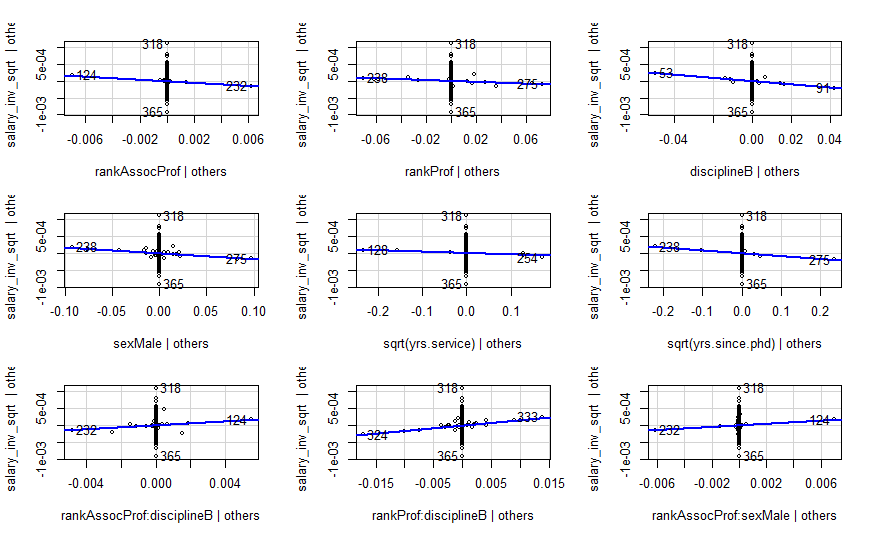

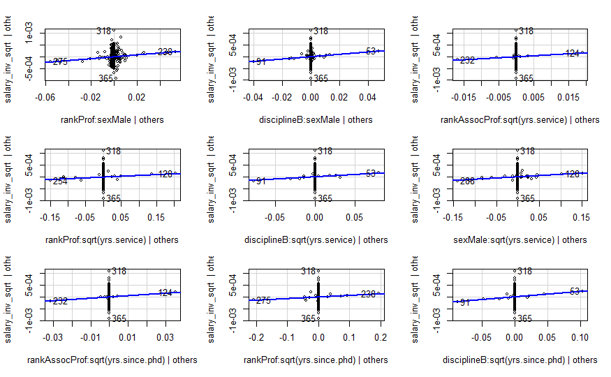

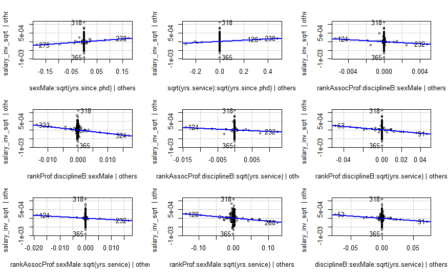

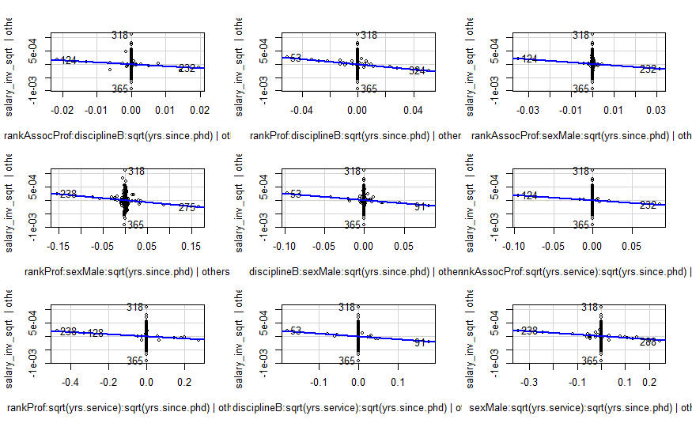

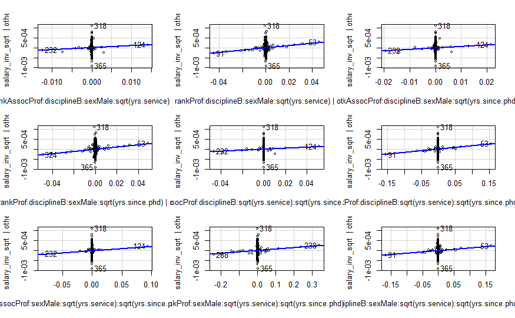

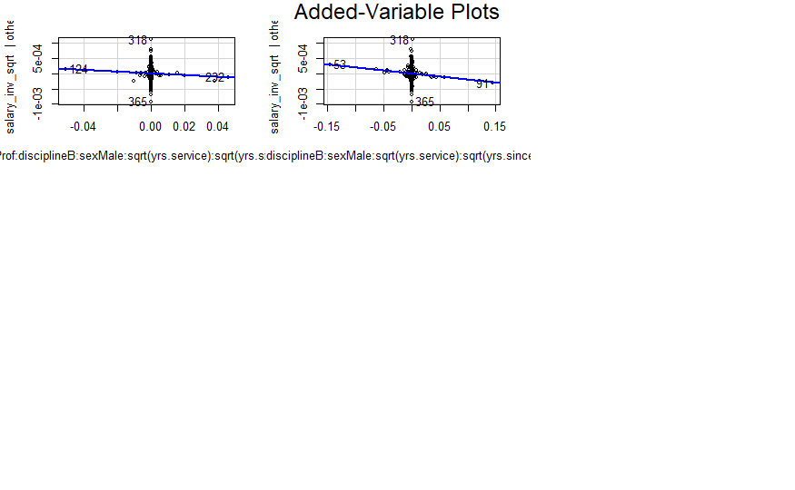

```r
avPlots(salarysqrt, ask = FALSE)
```

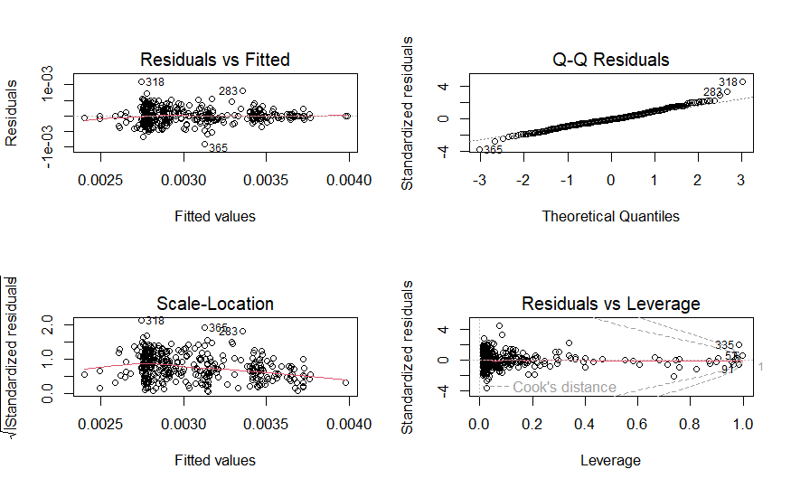

```r
par(mfrow = c(2,2), ask = FALSE)
plot(salarysqrt)
```

```
                    Test stat Pr(>|Test stat|)
rank
discipline
sex
sqrt(yrs.service)     -2.0086          0.04535 *
sqrt(yrs.since.phd)    1.1103          0.26763
Tukey test            -0.7157          0.47418
---
Signif. codes:  0 ‘***’ 0.001 ‘**’ 0.01 ‘*’ 0.05 ‘.’ 0.1 ‘ ’ 1
```

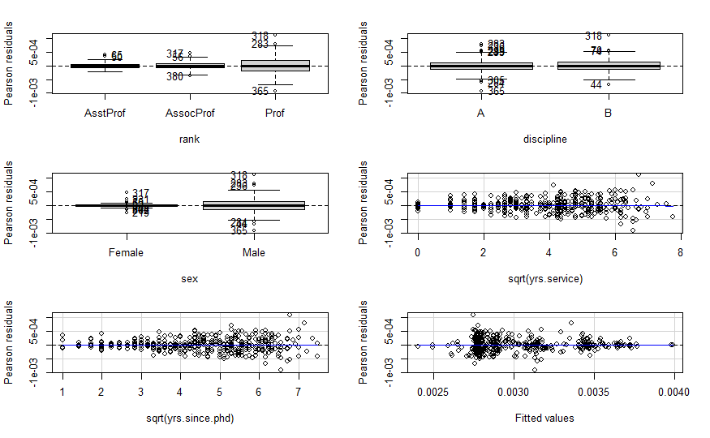

```r
residualPlots(salarysqrt, ask = FALSE)
```

```r
print(resettest(salarysqrt, power = 2:3, type = 'regressor'))
```

```
    RESET test

data:  salarysqrt
RESET = 1.1698, df1 = 4, df2 = 345, p-value = 0.3239
```

```r
print(resettest(salarysqrt, power = 2:3, type = 'fitted'))
```

```
    RESET test

data:  salarysqrt
RESET = 1.6006, df1 = 2, df2 = 347, p-value = 0.2033
```

```r
ncvTest(salarysqrt)
```

```
Non-constant Variance Score Test
Variance formula: ~ fitted.values
Chisquare = 26.69012, Df = 1, p = 2.3884e-07
```

```r
bptest(salarysqrt)
```

```
    studentized Breusch-Pagan test

data:  salarysqrt
BP = 67.462, df = 47, p-value = 0.02675
```

```r
vif(salarysqrt)
```

```
                                                                  GVIF Df GVIF^(1/(2*Df))
rank                                                      1.215463e+09  2       186.71766
discipline                                                1.898833e+04  1       137.79815
sex                                                       1.008603e+03  1        31.75851
sqrt(yrs.service)                                         8.076981e+03  1        89.87203
sqrt(yrs.since.phd)                                       7.265877e+03  1        85.24011
rank:discipline                                           4.435576e+10  2       458.92055
rank:sex                                                  1.776733e+09  2       205.30783
discipline:sex                                            2.006396e+04  1       141.64729
rank:sqrt(yrs.service)                                    1.289285e+10  2       336.96689
discipline:sqrt(yrs.service)                              1.144734e+05  1       338.33915
sex:sqrt(yrs.service)                                     1.702737e+04  1       130.48895
rank:sqrt(yrs.since.phd)                                  6.117470e+09  2       279.66812
discipline:sqrt(yrs.since.phd)                            9.173700e+04  1       302.88117
sex:sqrt(yrs.since.phd)                                   1.627428e+04  1       127.57068
sqrt(yrs.service):sqrt(yrs.since.phd)                     1.241546e+05  1       352.35581
rank:discipline:sex                                       3.765978e+10  2       440.52388
rank:discipline:sqrt(yrs.service)                         1.388446e+11  2       610.42489
rank:sex:sqrt(yrs.service)                                1.965854e+10  2       374.44479
discipline:sex:sqrt(yrs.service)                          1.232152e+05  1       351.02020
rank:discipline:sqrt(yrs.since.phd)                       6.285911e+10  2       500.71668
rank:sex:sqrt(yrs.since.phd)                              8.222344e+09  2       301.12645
discipline:sex:sqrt(yrs.since.phd)                        9.836073e+04  1       313.62514
rank:sqrt(yrs.service):sqrt(yrs.since.phd)                1.216314e+11  2       590.55642
discipline:sqrt(yrs.service):sqrt(yrs.since.phd)          7.104342e+05  1       842.87259
sex:sqrt(yrs.service):sqrt(yrs.since.phd)                 1.992718e+05  1       446.39869
rank:discipline:sex:sqrt(yrs.service)                     1.267959e+11  2       596.72785
rank:discipline:sex:sqrt(yrs.since.phd)                   5.526383e+10  2       484.85318
rank:discipline:sqrt(yrs.service):sqrt(yrs.since.phd)     5.792898e+11  2       872.41669
rank:sex:sqrt(yrs.service):sqrt(yrs.since.phd)            1.688329e+11  2       641.00920
discipline:sex:sqrt(yrs.service):sqrt(yrs.since.phd)      7.691850e+05  1       877.03192
rank:discipline:sex:sqrt(yrs.service):sqrt(yrs.since.phd) 5.685626e+11  2       868.34954
```

```r
outlierTest(salarysqrt)
```

|  | rstudent | unadjusted p-value | Bonferroni p |
| --- | --- | --- | --- |
| 318 | 4.674962 | 4.2114e-06 | 0.0016551 |

```r
inf <- data.frame(
  hat = hatvalues(salarysqrt),
  cooks = cooks.distance(salarysqrt),
  rstandard = rstandard(salarysqrt),
  rstudent = rstudent(salarysqrt)
)

infl <- infl[order(infl$cooks, decreasing = TRUE),]
print(head(infl))
```

|  | hat | cooks | rstudent | rstandard |
| --- | --- | --- | --- | --- |
| 318 | 0.07384809 | 0.06449086 | 4.5190632 | 4.4058144 |
| 195 | 0.90768009 | 0.05171278 | 0.3548758 | 0.3552923 |
| 331 | 0.21424591 | 0.04387580 | -1.9727965 | -1.9651930 |
| 351 | 0.18795949 | 0.03500683 | -1.9119619 | -1.9051918 |
| 283 | 0.07935775 | 0.03459357 | 3.1401625 | 3.1035169 |
| 115 | 0.29121266 | 0.02925820 | -1.3085689 | -1.3073211 |

We see that this model performs pretty similarly to the power-model with a better R-squared. This makes it a more interpretable. Now, we will eliminate the variables that seem insignificant and compare a sub-model to this one. Once again, sex seems to be the odd man out, which contradicts our t-test and permutation we did at the very beginning saying that there was a difference in pay between sexes.

```r
salarysqrt_mod <- lm(salary_inv_sqrt~rank+discipline+sqrt(yrs.service)+sqrt(yrs.since.phd)+discipline*sqrt(yrs.service)+discipline*sqrt(yrs.since.phd)+sqrt(yrs.service)*sqrt(yrs.since.phd)+discipline*sqrt(yrs.service)*sqrt(yrs.since.phd)+rank*discipline*sqrt(yrs.service)*sqrt(yrs.since.phd), data = Salaries)

print(summary(salarysqrt_mod))
```

```
Call:
lm(formula = salary_inv_sqrt ~ rank + discipline + sqrt(yrs.service) +
    sqrt(yrs.since.phd) + discipline * sqrt(yrs.service) + discipline *
    sqrt(yrs.since.phd) + sqrt(yrs.service) * sqrt(yrs.since.phd) +
    discipline * sqrt(yrs.service) * sqrt(yrs.since.phd) + rank *
    discipline * sqrt(yrs.service) * sqrt(yrs.since.phd), data = Salaries)

Residuals:
       Min         1Q     Median         3Q        Max
-9.112e-04 -1.466e-04 -1.312e-05  1.414e-04  1.105e-03

Coefficients:
                                                                  Estimate Std. Error t value Pr(>|t|)
(Intercept)                                                      3.647e-03  5.640e-04   6.466 3.16e-10 ***
rankAssocProf                                                   -8.096e-04  8.744e-04  -0.926  0.35513
rankProf                                                         1.630e-03  6.840e-04   2.382  0.01770 *
disciplineB                                                     -2.452e-04  6.113e-04  -0.401  0.68856
sqrt(yrs.service)                                                2.540e-04  3.750e-04   0.677  0.49872
sqrt(yrs.since.phd)                                             -2.977e-05  3.117e-04  -0.096  0.92395
disciplineB:sqrt(yrs.service)                                   -2.811e-04  4.203e-04  -0.669  0.50394
disciplineB:sqrt(yrs.since.phd)                                  9.344e-05  3.327e-04   0.281  0.77901
sqrt(yrs.service):sqrt(yrs.since.phd)                           -7.083e-05  1.745e-04  -0.406  0.68502
rankAssocProf:disciplineB                                        6.451e-04  1.059e-03   0.609  0.54271
rankProf:disciplineB                                            -2.338e-03  8.564e-04  -2.730  0.00664 **
rankAssocProf:sqrt(yrs.service)                                  1.105e-04  4.066e-04   0.272  0.78601
rankProf:sqrt(yrs.service)                                      -6.487e-04  3.850e-04  -1.685  0.09281 .
rankAssocProf:sqrt(yrs.since.phd)                                1.909e-05  3.777e-04   0.051  0.95972
rankProf:sqrt(yrs.since.phd)                                    -5.127e-04  3.223e-04  -1.591  0.11245
disciplineB:sqrt(yrs.service):sqrt(yrs.since.phd)                5.402e-05  1.950e-04   0.277  0.78193
rankAssocProf:disciplineB:sqrt(yrs.service)                     -8.305e-05  4.764e-04  -0.174  0.86171
rankProf:disciplineB:sqrt(yrs.service)                           6.759e-04  4.405e-04   1.534  0.12581
rankAssocProf:disciplineB:sqrt(yrs.since.phd)                   -1.329e-04  4.186e-04  -0.317  0.75109
rankProf:disciplineB:sqrt(yrs.since.phd)                         4.862e-04  3.568e-04   1.362  0.17387
rankAssocProf:sqrt(yrs.service):sqrt(yrs.since.phd)              3.558e-05  1.775e-04   0.200  0.84125
rankProf:sqrt(yrs.service):sqrt(yrs.since.phd)                   1.635e-04  1.752e-04   0.934  0.35103
rankAssocProf:disciplineB:sqrt(yrs.service):sqrt(yrs.since.phd) -1.062e-05  2.000e-04  -0.053  0.95768
rankProf:disciplineB:sqrt(yrs.service):sqrt(yrs.since.phd)      -1.512e-04  1.965e-04  -0.769  0.44223
---
Signif. codes:  0 ‘***’ 0.001 ‘**’ 0.01 ‘*’ 0.05 ‘.’ 0.1 ‘ ’ 1

Residual standard error: 0.0002518 on 373 degrees of freedom
Multiple R-squared:  0.6124,    Adjusted R-squared:  0.5885
F-statistic: 25.63 on 23 and 373 DF,  p-value: < 2.2e-16
```

```r
Anova(salarysqrt_mod, type = 'III')
```

```
Anova Table (Type III tests)

Response: salary_inv_sqrt
                                                          Sum Sq  Df F value    Pr(>F)
(Intercept)                                           2.6513e-06   1 41.8071 3.160e-10 ***
rank                                                  7.8510e-07   2  6.1902  0.002266 **
discipline                                            1.0200e-08   1  0.1609  0.688557
sqrt(yrs.service)                                     2.9100e-08   1  0.4586  0.498716
sqrt(yrs.since.phd)                                   6.0000e-10   1  0.0091  0.923947
discipline:sqrt(yrs.service)                          2.8400e-08   1  0.4475  0.503939
discipline:sqrt(yrs.since.phd)                        5.0000e-09   1  0.0789  0.779009
sqrt(yrs.service):sqrt(yrs.since.phd)                 1.0500e-08   1  0.1648  0.685020
rank:discipline                                       7.0230e-07   2  5.5369  0.004269 **
rank:sqrt(yrs.service)                                1.2301e-06   2  9.6980 7.836e-05 ***
rank:sqrt(yrs.since.phd)                              4.6470e-07   2  3.6641  0.026555 *
discipline:sqrt(yrs.service):sqrt(yrs.since.phd)      4.9000e-09   1  0.0767  0.781934
rank:discipline:sqrt(yrs.service)                     6.1640e-07   2  4.8596  0.008251 **
rank:discipline:sqrt(yrs.since.phd)                   3.6560e-07   2  2.8823  0.057256 .
rank:sqrt(yrs.service):sqrt(yrs.since.phd)            8.3770e-07   2  6.6043  0.001518 **
rank:discipline:sqrt(yrs.service):sqrt(yrs.since.phd) 5.0900e-07   2  4.0131  0.018863 *
Residuals                                             2.3655e-05 373
---
Signif. codes:  0 ‘***’ 0.001 ‘**’ 0.01 ‘*’ 0.05 ‘.’ 0.1 ‘ ’ 1
```

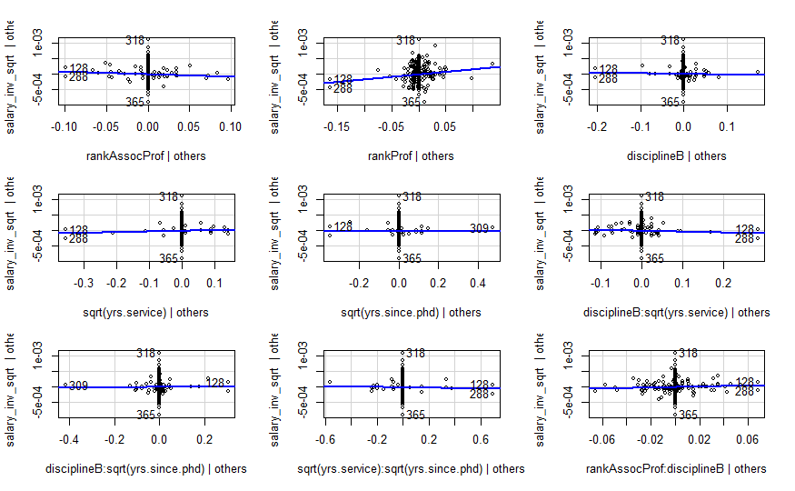

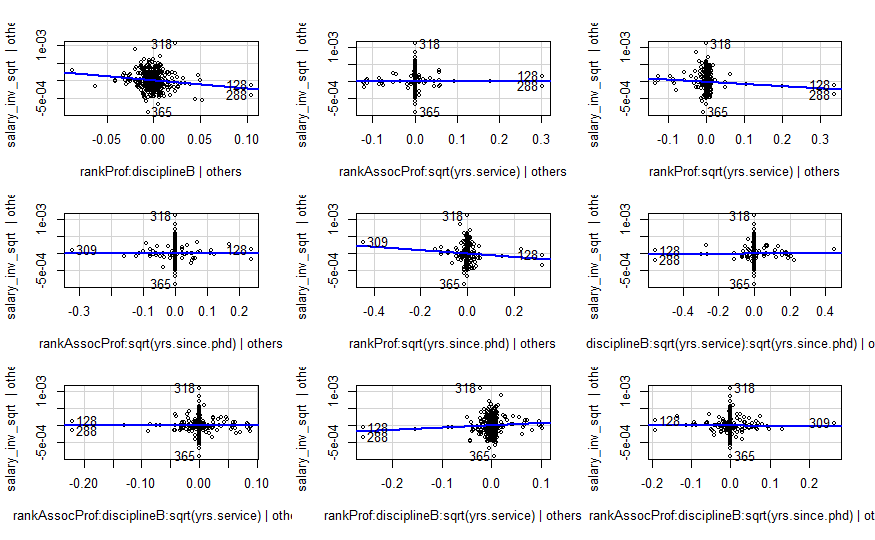

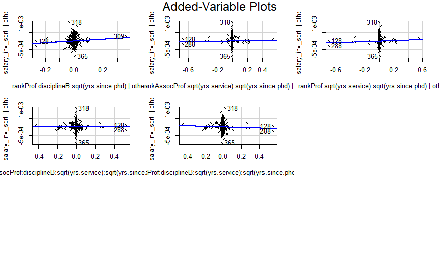

```r
avPlots(salarysqrt_mod, ask = FALSE)
```

```r
anova(salarysqrt_mod, salarysqrt)
```

```
Analysis of Variance Table

Model 1: salary_inv_sqrt ~ rank + discipline + sqrt(yrs.service) + sqrt(yrs.since.phd) +
    discipline * sqrt(yrs.service) + discipline * sqrt(yrs.since.phd) +
    sqrt(yrs.service) * sqrt(yrs.since.phd) + discipline * sqrt(yrs.service) *
    sqrt(yrs.since.phd) + rank * discipline * sqrt(yrs.service) *
    sqrt(yrs.since.phd)
Model 2: salary_inv_sqrt ~ rank * discipline * sex * sqrt(yrs.service) *
    sqrt(yrs.since.phd)
  Res.Df        RSS Df  Sum of Sq      F Pr(>F)
1    373 2.3655e-05
2    349 2.2261e-05 24 1.3936e-06 0.9104 0.5881
```

Our ANOVA tells us that the sub-model is the way to go, so we shall proceed.

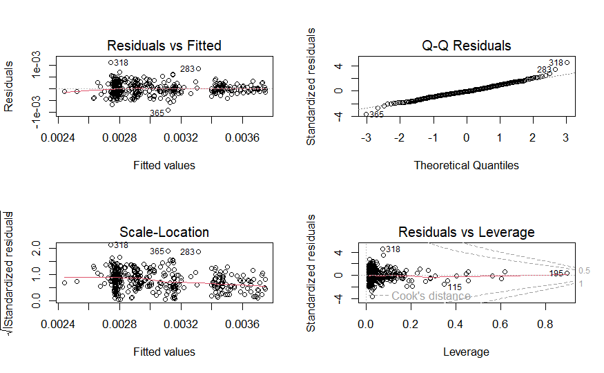

```r
par(mfrow = c(2,2), ask = FALSE)
plot(salarysqrt_mod)
```

```
                    Test stat Pr(>|Test stat|)
rank
discipline
sqrt(yrs.service)     -2.3629          0.01865 *
sqrt(yrs.since.phd)    1.3430          0.18010
Tukey test            -0.7296          0.46566
---
Signif. codes:  0 ‘***’ 0.001 ‘**’ 0.01 ‘*’ 0.05 ‘.’ 0.1 ‘ ’ 1
```

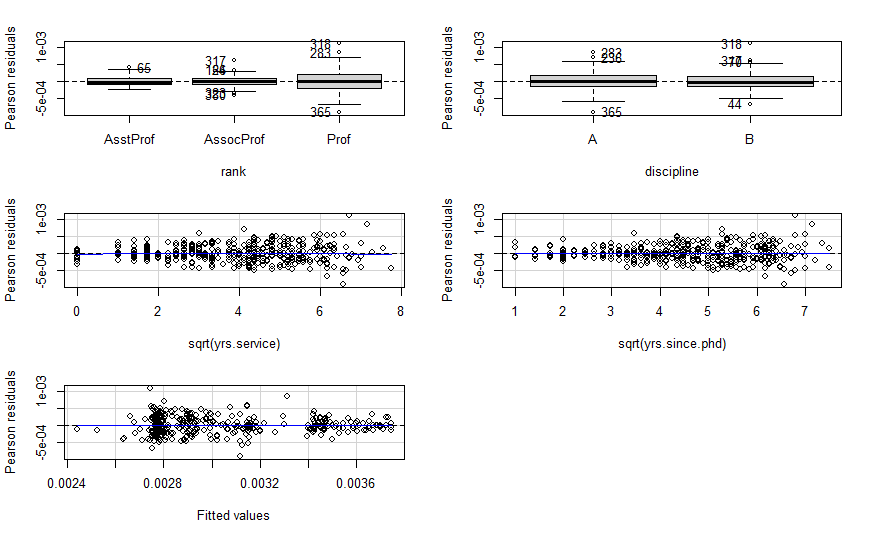

```r
residualPlots(salarysqrt_mod, ask = FALSE)
```

```r
print(resettest(salarysqrt_mod, power = 2:3, type = 'regressor'))
```

```
    RESET test

data:  salarysqrt_mod
RESET = 1.403, df1 = 4, df2 = 369, p-value = 0.2324
```

```r
print(resettest(salarysqrt_mod, power = 2:3, type = 'fitted'))
```

```
    RESET test

data:  salarysqrt_mod
RESET = 1.4708, df1 = 2, df2 = 371, p-value = 0.2311
```

```r
ncvTest(salarysqrt_mod)
```

```
Non-constant Variance Score Test
Variance formula: ~ fitted.values
Chisquare = 22.65537, Df = 1, p = 1.9382e-06
```

```r
bptest(salarysqrt_mod)
```

```
    studentized Breusch-Pagan test

data:  salarysqrt_mod
BP = 59.458, df = 23, p-value = 4.574e-05
```

```r
vif(salarysqrt_mod)
```

```
                                                              GVIF Df GVIF^(1/(2*Df))
rank                                                    183270.958  2        20.69062
discipline                                                 580.200  1        24.08734
sqrt(yrs.service)                                         2537.042  1        50.36905
sqrt(yrs.since.phd)                                       1327.892  1        36.44025
discipline:sqrt(yrs.service)                              5173.689  1        71.92836
discipline:sqrt(yrs.since.phd)                            3826.774  1        61.86092
sqrt(yrs.service):sqrt(yrs.since.phd)                    31477.245  1       177.41828
rank:discipline                                         491265.642  2        26.47458
rank:sqrt(yrs.service)                                 1290700.963  2        33.70594
rank:sqrt(yrs.since.phd)                               2007769.488  2        37.64250
discipline:sqrt(yrs.service):sqrt(yrs.since.phd)         36118.121  1       190.04768
rank:discipline:sqrt(yrs.service)                      2265822.911  2        38.79775
rank:discipline:sqrt(yrs.since.phd)                    2694505.764  2        40.51537
rank:sqrt(yrs.service):sqrt(yrs.since.phd)            11329218.374  2        58.01629
rank:discipline:sqrt(yrs.service):sqrt(yrs.since.phd) 11033176.109  2        57.63352
```

```r
outlierTest(salarysqrt_mod)
```

|  | rstudent | unadjusted p-value | Bonferroni p |
| --- | --- | --- | --- |
| 318 | 4.683621 | 3.9574e-06 | 0.0015711 |

```r
infl <- data.frame(
  hat = hatvalues(salarysqrt_mod),
  cooks = cooks.distance(salarysqrt_mod),
  rstudent = rstudent(salarysqrt_mod),
  rstandard = rstandard(salarysqrt_mod)
)

infl <- infl[order(infl$cooks, decreasing = TRUE),]

print(head(infl))
```

|  | hat | cooks | rstudent | rstandard |
| --- | --- | --- | --- | --- |
| 318 | 0.07303103 | 0.06818317 | 4.6836205 | 4.5574626 |
| 195 | 0.89661129 | 0.05189859 | 0.3785459 | 0.3789814 |
| 115 | 0.34641871 | 0.05148469 | -1.5295803 | -1.5268409 |
| 283 | 0.07658338 | 0.04242634 | 3.5582777 | 3.5039264 |
| 331 | 0.20686529 | 0.04010949 | -1.9281252 | -1.9211392 |
| 351 | 0.17993537 | 0.03174111 | -1.8695203 | -1.8632986 |

This performs very similar to the modified power-model, but even better! In fact this is our best model so far as far as meeting our linear regression assumptions.

We will try one last model, this time with a log calculation on the response variable, salary, as well as log transformations on the continuous predictor variables.

```r
salarylog <- lm(log(salary)~rank*discipline*sex*log(yrs_service_plus)*log(yrs.since.phd), data = Salaries)
print(summary(salarylog))
```

```
Call:
lm(formula = log(salary) ~ rank * discipline * sex * log(yrs_service_plus) *
    log(yrs.since.phd), data = Salaries)

Residuals:
     Min       1Q   Median       3Q      Max
-0.68156 -0.09456  0.00446  0.08719  0.67276

Coefficients:
                                                                            Estimate Std. Error t value Pr(>|t|)
(Intercept)                                                                 10.80345    0.58332  18.520  < 2e-16 ***
rankAssocProf                                                               27.07704   41.20791   0.657  0.51156
rankProf                                                                    -0.43634    1.64118  -0.266  0.79050
disciplineB                                                                  1.77580    1.51571   1.172  0.24216
sexMale                                                                      0.34621    0.61996   0.558  0.57691
log(yrs_service_plus)                                                        0.08730    0.17292   0.505  0.61399
log(yrs.since.phd)                                                           0.39837    0.51211   0.778  0.43716
rankAssocProf:disciplineB                                                  -31.18717   43.23257  -0.721  0.47116
rankProf:disciplineB                                                       -18.81627   11.59562  -1.623  0.10556
rankAssocProf:sexMale                                                      -26.83380   41.21880  -0.651  0.51547
rankProf:sexMale                                                            -3.20871    1.79169  -1.791  0.07418 .
disciplineB:sexMale                                                         -1.58109    1.53210  -1.032  0.30280
rankAssocProf:log(yrs_service_plus)                                        -12.66687   19.81843  -0.639  0.52315
rankProf:log(yrs_service_plus)                                              -0.20137    0.41590  -0.484  0.62856
disciplineB:log(yrs_service_plus)                                           -1.05070    1.18765  -0.885  0.37693
sexMale:log(yrs_service_plus)                                               -0.21263    0.21223  -1.002  0.31710
rankAssocProf:log(yrs.since.phd)                                            -8.65110   12.68146  -0.682  0.49557
rankProf:log(yrs.since.phd)                                                  0.01967    0.77229   0.025  0.97969
disciplineB:log(yrs.since.phd)                                              -1.20024    1.02713  -1.169  0.24339
sexMale:log(yrs.since.phd)                                                  -0.37387    0.53053  -0.705  0.48146
log(yrs_service_plus):log(yrs.since.phd)                                    -0.19224    0.21072  -0.912  0.36223
rankAssocProf:disciplineB:sexMale                                           30.95645   43.24849   0.716  0.47461
rankProf:disciplineB:sexMale                                                22.99592   11.63968   1.976  0.04898 *
rankAssocProf:disciplineB:log(yrs_service_plus)                             14.22405   20.94250   0.679  0.49746
rankProf:disciplineB:log(yrs_service_plus)                                   6.83399    3.89763   1.753  0.08042 .
rankAssocProf:sexMale:log(yrs_service_plus)                                 12.64850   19.82071   0.638  0.52380
rankProf:sexMale:log(yrs_service_plus)                                       1.53859    0.49589   3.103  0.00207 **
disciplineB:sexMale:log(yrs_service_plus)                                    1.17379    1.19503   0.982  0.32667
rankAssocProf:disciplineB:log(yrs.since.phd)                                10.27921   13.67961   0.751  0.45290
rankProf:disciplineB:log(yrs.since.phd)                                      6.83654    3.97300   1.721  0.08618 .
```

[output cut: 9 more lines]

```
rankAssocProf:disciplineB:sexMale:log(yrs.since.phd)                       -10.23218   13.68863  -0.747  0.45527
rankProf:disciplineB:sexMale:log(yrs.since.phd)                             -8.29278    3.98885  -2.079  0.03835 *
rankAssocProf:disciplineB:log(yrs_service_plus):log(yrs.since.phd)          -4.75681    6.68807  -0.711  0.47741
rankProf:disciplineB:log(yrs_service_plus):log(yrs.since.phd)               -2.67349    1.43844  -1.859  0.06393 .
rankAssocProf:sexMale:log(yrs_service_plus):log(yrs.since.phd)              -4.13720    6.09259  -0.679  0.49755
rankProf:sexMale:log(yrs_service_plus):log(yrs.since.phd)                   -0.69698    0.27987  -2.490  0.01322 *
disciplineB:sexMale:log(yrs_service_plus):log(yrs.since.phd)                -0.86624    0.74967  -1.155  0.24868
rankAssocProf:disciplineB:sexMale:log(yrs_service_plus):log(yrs.since.phd)   4.78057    6.69022   0.715  0.47536
rankProf:disciplineB:sexMale:log(yrs_service_plus):log(yrs.since.phd)        3.16582    1.44473   2.191  0.02909 *
---
Signif. codes:  0 ‘***’ 0.001 ‘**’ 0.01 ‘*’ 0.05 ‘.’ 0.1 ‘ ’ 1

Residual standard error: 0.1752 on 349 degrees of freedom
Multiple R-squared:  0.6003,    Adjusted R-squared:  0.5465
F-statistic: 11.15 on 47 and 349 DF,  p-value: < 2.2e-16
```

```r
Anova(salarylog, type = 'III')
```

```
Anova Table (Type III tests)

Response: log(salary)
                                                              Sum Sq  Df  F value    Pr(>F)
(Intercept)                                                  10.5302   1 343.0085 < 2.2e-16 ***
rank                                                          0.0155   2   0.2521  0.777303
discipline                                                    0.0421   1   1.3726  0.242159
sex                                                           0.0096   1   0.3118  0.576909
log(yrs_service_plus)                                         0.0078   1   0.2549  0.613985
log(yrs.since.phd)                                            0.0186   1   0.6051  0.437156
rank:discipline                                               0.0965   2   1.5714  0.209210
rank:sex                                                      0.1111   2   1.8095  0.165264
discipline:sex                                                0.0327   1   1.0650  0.302799
rank:log(yrs_service_plus)                                    0.0197   2   0.3203  0.726108
discipline:log(yrs_service_plus)                              0.0240   1   0.7827  0.376932
sex:log(yrs_service_plus)                                     0.0308   1   1.0037  0.317105
rank:log(yrs.since.phd)                                       0.0143   2   0.2336  0.791766
discipline:log(yrs.since.phd)                                 0.0419   1   1.3655  0.243389
sex:log(yrs.since.phd)                                        0.0152   1   0.4966  0.481461
log(yrs_service_plus):log(yrs.since.phd)                      0.0256   1   0.8323  0.362228
rank:discipline:sex                                           0.1352   2   2.2012  0.112203
rank:discipline:log(yrs_service_plus)                         0.1073   2   1.7477  0.175687
rank:sex:log(yrs_service_plus)                                0.3075   2   5.0080  0.007173 **
discipline:sex:log(yrs_service_plus)                          0.0296   1   0.9648  0.326669
rank:discipline:log(yrs.since.phd)                            0.1067   2   1.7384  0.177326
rank:sex:log(yrs.since.phd)                                   0.1020   2   1.6612  0.191408
discipline:sex:log(yrs.since.phd)                             0.0390   1   1.2705  0.260442
rank:log(yrs_service_plus):log(yrs.since.phd)                 0.0330   2   0.5374  0.584761
discipline:log(yrs_service_plus):log(yrs.since.phd)           0.0358   1   1.1672  0.280722
sex:log(yrs_service_plus):log(yrs.since.phd)                  0.0418   1   1.3607  0.244219
rank:discipline:sex:log(yrs_service_plus)                     0.1469   2   2.3933  0.092827 .
rank:discipline:sex:log(yrs.since.phd)                        0.1480   2   2.4108  0.091240 .
rank:discipline:log(yrs_service_plus):log(yrs.since.phd)      0.1173   2   1.9103  0.149584
rank:sex:log(yrs_service_plus):log(yrs.since.phd)             0.2016   2   3.2842  0.038630 *
discipline:sex:log(yrs_service_plus):log(yrs.since.phd)       0.0410   1   1.3352  0.248681
rank:discipline:sex:log(yrs_service_plus):log(yrs.since.phd)  0.1580   2   2.5738  0.077691 .
Residuals                                                    10.7141 349
---
Signif. codes:  0 ‘***’ 0.001 ‘**’ 0.01 ‘*’ 0.05 ‘.’ 0.1 ‘ ’ 1
```

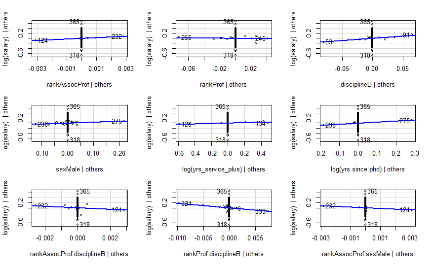

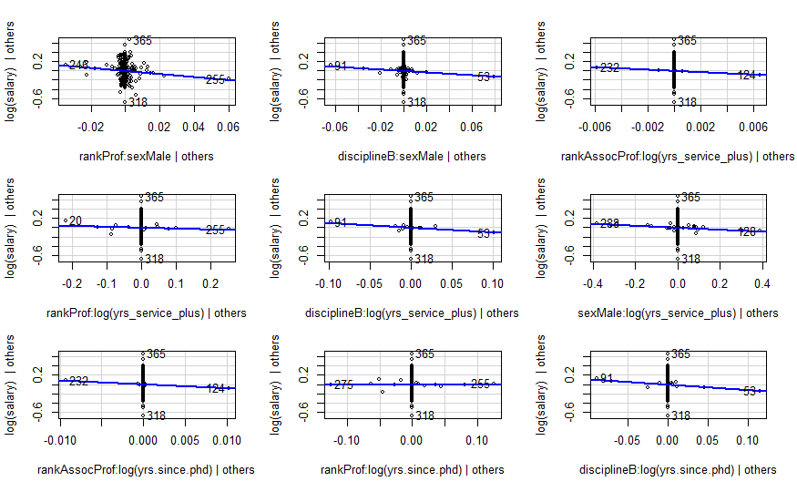

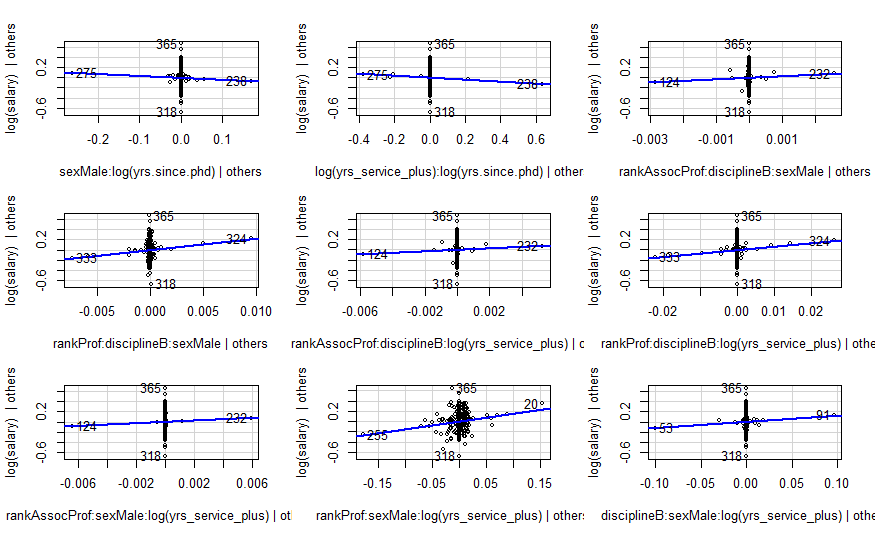

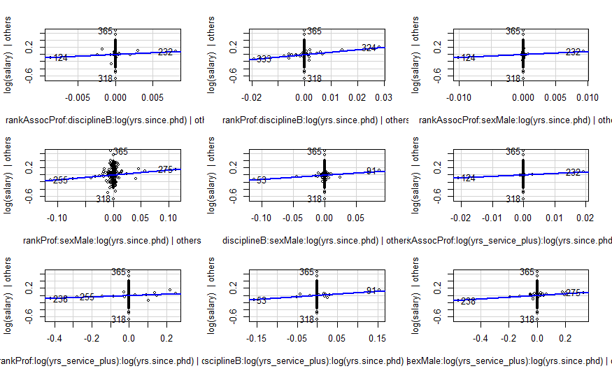

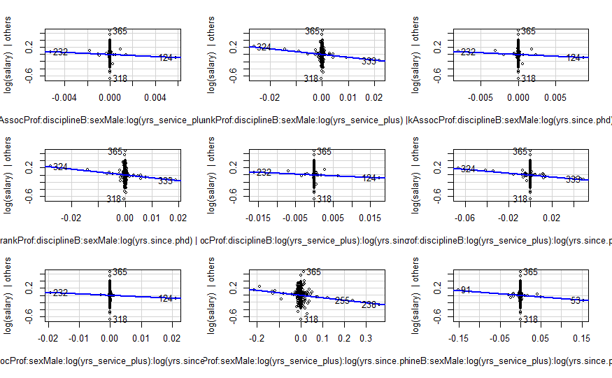

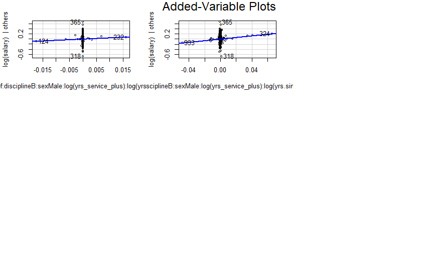

```r
avPlots(salarylog, ask = FALSE)
```

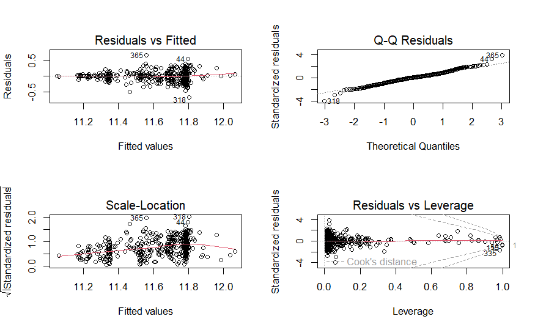

```r
par(mfrow = c(2,2), ask = FALSE)
plot(salarylog)
```

```
                      Test stat Pr(>|Test stat|)
rank
discipline
sex
log(yrs_service_plus)    1.5379           0.1250
log(yrs.since.phd)      -1.2808           0.2011
Tukey test               1.5538           0.1202
```

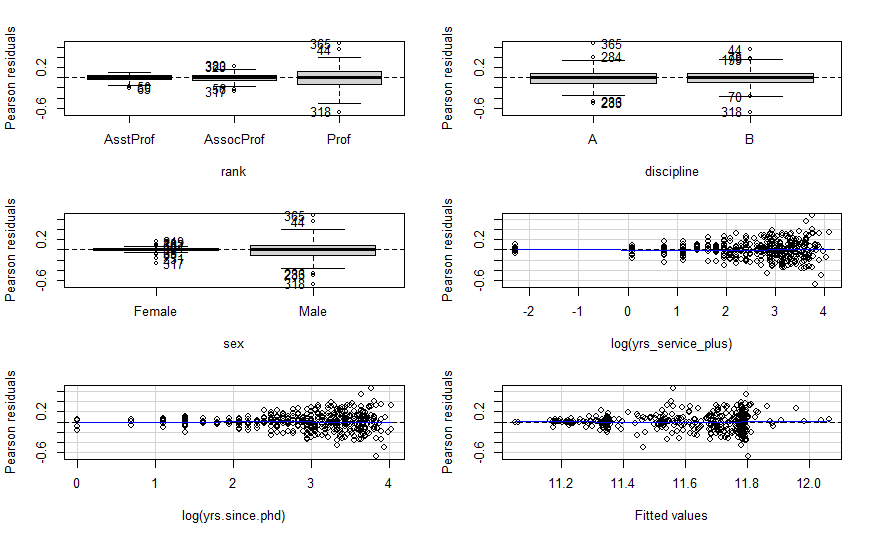

```r
residualPlots(salarylog, ask = FALSE)
```

```r
print(resettest(salarylog, power = 2:3, type = 'regressor'))
```

```
    RESET test

data:  salarylog
RESET = 0.82167, df1 = 4, df2 = 345, p-value = 0.512
```

```r
print(resettest(salarylog, power = 2:3, type = 'fitted'))
```

```
    RESET test

data:  salarylog
RESET = 1.3737, df1 = 2, df2 = 347, p-value = 0.2545
```

```r
ncvTest(salarylog)
```

```
Non-constant Variance Score Test
Variance formula: ~ fitted.values
Chisquare = 41.23178, Df = 1, p = 1.3521e-10
```

```r
bptest(salarylog)
```

```
    studentized Breusch-Pagan test

data:  salarylog
BP = 73.322, df = 47, p-value = 0.008326
```

```r
vif(salarylog)
```

```
                                                                     GVIF Df GVIF^(1/(2*Df))
rank                                                         1.394269e+10  2       343.62652
discipline                                                   7.369627e+03  1        85.84653
sex                                                          4.403105e+02  1        20.98358
log(yrs_service_plus)                                        5.825289e+02  1        24.13563
log(yrs.since.phd)                                           2.142782e+03  1        46.29019
rank:discipline                                              7.718154e+11  2       937.29944
rank:sex                                                     1.854466e+10  2       369.02409
discipline:sex                                               7.586449e+03  1        87.10023
rank:log(yrs_service_plus)                                   1.369085e+10  2       342.06417
discipline:log(yrs_service_plus)                             3.903202e+04  1       197.56523
sex:log(yrs_service_plus)                                    1.056727e+03  1        32.50734
rank:log(yrs.since.phd)                                      2.411069e+10  2       394.05097
discipline:log(yrs.since.phd)                                3.015745e+04  1       173.65900
sex:log(yrs.since.phd)                                       4.775329e+03  1        69.10376
log(yrs_service_plus):log(yrs.since.phd)                     1.114452e+04  1       105.56763
rank:discipline:sex                                          6.501792e+11  2       897.96264
rank:discipline:log(yrs_service_plus)                        9.779773e+11  2       994.44827
rank:sex:log(yrs_service_plus)                               1.966666e+10  2       374.48346
discipline:sex:log(yrs_service_plus)                         3.871219e+04  1       196.75414
rank:discipline:log(yrs.since.phd)                           6.214022e+11  2       887.85734
rank:sex:log(yrs.since.phd)                                  2.912740e+10  2       413.11924
discipline:sex:log(yrs.since.phd)                            3.093905e+04  1       175.89500
rank:log(yrs_service_plus):log(yrs.since.phd)                5.745102e+10  2       489.58086
discipline:log(yrs_service_plus):log(yrs.since.phd)          1.607104e+05  1       400.88700
sex:log(yrs_service_plus):log(yrs.since.phd)                 1.500816e+04  1       122.50780
rank:discipline:sex:log(yrs_service_plus)                    8.398917e+11  2       957.31711
rank:discipline:sex:log(yrs.since.phd)                       5.247588e+11  2       851.11830
rank:discipline:log(yrs_service_plus):log(yrs.since.phd)     1.159211e+12  2      1037.62539
rank:sex:log(yrs_service_plus):log(yrs.since.phd)            6.668865e+10  2       508.17462
discipline:sex:log(yrs_service_plus):log(yrs.since.phd)      1.615144e+05  1       401.88855
rank:discipline:sex:log(yrs_service_plus):log(yrs.since.phd) 1.023060e+12  2      1005.71570
```

```r
outlierTest(salarylog)
```

|  | rstudent | unadjusted p-value | Bonferroni p |
| --- | --- | --- | --- |
| 318 | -4.105191 | 5.0381e-05 | 0.019800 |
| 365 | 3.974598 | 8.5742e-05 | 0.033697 |

```r
infl <- data.frame(
  hat = hatvalues(salarylog),
  cooks = cooks.distance(salarylog),
  rstudent = rstudent(salarylog),
  rstandard = rstandard(salarylog)
)

infl <- infl[order(infl$cooks, decreasing = TRUE),]
print(head(infl))
```

|  | hat | cooks | rstudent | rstandard |
| --- | --- | --- | --- | --- |
| 115 | 0.9978153 | 6.0189734 | -0.7949160 | -0.7953355 |
| 335 | 0.9830351 | 3.7241196 | -1.7616848 | -1.7563996 |
| 53 | 0.9967328 | 2.5794004 | -0.6365156 | -0.6370588 |
| 36 | 0.9853913 | 0.5703164 | 0.6365156 | 0.6370588 |
| 219 | 0.7469258 | 0.2001650 | 1.8101386 | 1.8042633 |
| 91 | 0.9587776 | 0.1966538 | 0.6365156 | 0.6370588 |

This one does not perform as bad as I thought, it violates the same thing the power-model and the square-root-models do in similar quantities. The R-squared is worse here than on the square-root-model. We will once again reduce some of the variables, but this time, I will chose to keep sex in seeing as how the first two models are fundamentally very similar, I want to see if keeping sex changes anything.

```r
salarylog_mod <- lm(log(salary)~rank+discipline+log(yrs_service_plus)+log(yrs.since.phd)+discipline*log(yrs_service_plus)+discipline*log(yrs.since.phd)+log(yrs_service_plus)*log(yrs.since.phd)+discipline*log(yrs_service_plus)*log(yrs.since.phd)+rank*discipline*log(yrs_service_plus)*log(yrs.since.phd)+rank*sex*log(yrs_service_plus)*log(yrs.since.phd), data = Salaries)
print(summary(salarylog_mod))
```

```
Call:
lm(formula = log(salary) ~ rank + discipline + log(yrs_service_plus) +
    log(yrs.since.phd) + discipline * log(yrs_service_plus) +
    discipline * log(yrs.since.phd) + log(yrs_service_plus) *
    log(yrs.since.phd) + discipline * log(yrs_service_plus) *
    log(yrs.since.phd) + rank * discipline * log(yrs_service_plus) *
    log(yrs.since.phd) + rank * sex * log(yrs_service_plus) *
    log(yrs.since.phd), data = Salaries)

Residuals:
     Min       1Q   Median       3Q      Max
-0.67873 -0.09878  0.00822  0.08732  0.67207

Coefficients:
                                                                    Estimate Std. Error t value Pr(>|t|)
(Intercept)                                                        11.171353   0.247958  45.053  < 2e-16 ***
rankAssocProf                                                      -2.329449   6.232377  -0.374 0.708798
rankProf                                                           -0.003065   1.294841  -0.002 0.998113
disciplineB                                                         0.195828   0.207868   0.942 0.346781
log(yrs_service_plus)                                              -0.009657   0.128733  -0.075 0.940245
log(yrs.since.phd)                                                  0.016024   0.175844   0.091 0.927444
sexMale                                                            -0.029064   0.233787  -0.124 0.901134
disciplineB:log(yrs_service_plus)                                   0.099528   0.124766   0.798 0.425562
disciplineB:log(yrs.since.phd)                                     -0.038776   0.140682  -0.276 0.782991
log(yrs_service_plus):log(yrs.since.phd)                            0.004459   0.094329   0.047 0.962323
rankAssocProf:disciplineB                                          -0.350223   1.151844  -0.304 0.761262
rankProf:disciplineB                                                3.822192   0.997958   3.830 0.000151 ***
rankAssocProf:log(yrs_service_plus)                                 0.913970   2.610543   0.350 0.726462
rankProf:log(yrs_service_plus)                                     -0.102107   0.379254  -0.269 0.787907
rankAssocProf:log(yrs.since.phd)                                    0.954398   2.116612   0.451 0.652326
rankProf:log(yrs.since.phd)                                         0.123865   0.519237   0.239 0.811589
rankAssocProf:sexMale                                               2.664433   6.200181   0.430 0.667645
rankProf:sexMale                                                   -3.465782   1.474056  -2.351 0.019251 *
log(yrs_service_plus):sexMale                                      -0.096688   0.151394  -0.639 0.523456
log(yrs.since.phd):sexMale                                          0.019707   0.155685   0.127 0.899343
disciplineB:log(yrs_service_plus):log(yrs.since.phd)               -0.039255   0.082264  -0.477 0.633526
rankAssocProf:disciplineB:log(yrs_service_plus)                     0.118126   0.400205   0.295 0.768038
rankProf:disciplineB:log(yrs_service_plus)                         -1.196996   0.351370  -3.407 0.000732 ***
rankAssocProf:disciplineB:log(yrs.since.phd)                        0.107050   0.486026   0.220 0.825796
rankProf:disciplineB:log(yrs.since.phd)                            -1.334657   0.349246  -3.822 0.000156 ***
rankAssocProf:log(yrs_service_plus):log(yrs.since.phd)             -0.367687   0.864991  -0.425 0.671035
rankProf:log(yrs_service_plus):log(yrs.since.phd)                   0.034766   0.169789   0.205 0.837875
rankAssocProf:log(yrs_service_plus):sexMale                        -0.972240   2.589620  -0.375 0.707556
rankProf:log(yrs_service_plus):sexMale                              1.349364   0.458674   2.942 0.003473 **
rankAssocProf:log(yrs.since.phd):sexMale                           -0.943493   2.095607  -0.450 0.652819
rankProf:log(yrs.since.phd):sexMale                                 1.223877   0.557834   2.194 0.028874 *
log(yrs_service_plus):log(yrs.since.phd):sexMale                    0.048565   0.101086   0.480 0.631214
rankAssocProf:disciplineB:log(yrs_service_plus):log(yrs.since.phd) -0.012480   0.165484  -0.075 0.939927
rankProf:disciplineB:log(yrs_service_plus):log(yrs.since.phd)       0.428972   0.130922   3.277 0.001153 **
rankAssocProf:log(yrs_service_plus):log(yrs.since.phd):sexMale      0.331049   0.858138   0.386 0.699890
rankProf:log(yrs_service_plus):log(yrs.since.phd):sexMale          -0.484083   0.188670  -2.566 0.010698 *
---
Signif. codes:  0 ‘***’ 0.001 ‘**’ 0.01 ‘*’ 0.05 ‘.’ 0.1 ‘ ’ 1

Residual standard error: 0.1749 on 361 degrees of freedom
Multiple R-squared:  0.5879,    Adjusted R-squared:  0.5479
F-statistic: 14.71 on 35 and 361 DF,  p-value: < 2.2e-16
```

```r
Anova(salarylog_mod, type = 'III')
```

```
Anova Table (Type III tests)

Response: log(salary)
                                                         Sum Sq  Df   F value    Pr(>F)
(Intercept)                                              62.120   1 2029.8088 < 2.2e-16 ***
rank                                                      0.004   2    0.0699 0.9325458
discipline                                                0.027   1    0.8875 0.3467811
log(yrs_service_plus)                                     0.000   1    0.0056 0.9402451
log(yrs.since.phd)                                        0.000   1    0.0083 0.9274439
sex                                                       0.000   1    0.0155 0.9011336
discipline:log(yrs_service_plus)                          0.019   1    0.6363 0.4255623
discipline:log(yrs.since.phd)                             0.002   1    0.0760 0.7829910
log(yrs_service_plus):log(yrs.since.phd)                  0.000   1    0.0022 0.9623232
rank:discipline                                           0.455   2    7.4350 0.0006851 ***
rank:log(yrs_service_plus)                                0.006   2    0.0991 0.9056447
rank:log(yrs.since.phd)                                   0.008   2    0.1272 0.8806085
rank:sex                                                  0.175   2    2.8625 0.0584222 .
log(yrs_service_plus):sex                                 0.012   1    0.4079 0.5234555
log(yrs.since.phd):sex                                    0.000   1    0.0160 0.8993432
discipline:log(yrs_service_plus):log(yrs.since.phd)       0.007   1    0.2277 0.6335257
rank:discipline:log(yrs_service_plus)                     0.369   2    6.0314 0.0026510 **
rank:discipline:log(yrs.since.phd)                        0.461   2    7.5268 0.0006273 ***
rank:log(yrs_service_plus):log(yrs.since.phd)             0.007   2    0.1170 0.8896093
rank:log(yrs_service_plus):sex                            0.271   2    4.4208 0.0126829 *
rank:log(yrs.since.phd):sex                               0.155   2    2.5297 0.0810949 .
log(yrs_service_plus):log(yrs.since.phd):sex              0.007   1    0.2308 0.6312142
rank:discipline:log(yrs_service_plus):log(yrs.since.phd)  0.370   2    6.0369 0.0026368 **
rank:log(yrs_service_plus):log(yrs.since.phd):sex         0.211   2    3.4422 0.0330486 *
Residuals                                                11.048 361
---
Signif. codes:  0 ‘***’ 0.001 ‘**’ 0.01 ‘*’ 0.05 ‘.’ 0.1 ‘ ’ 1
```

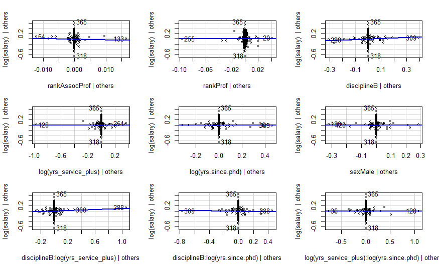

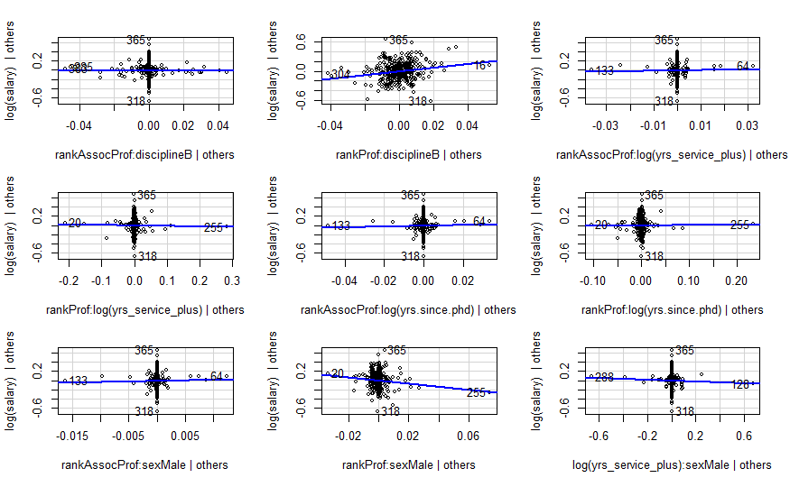

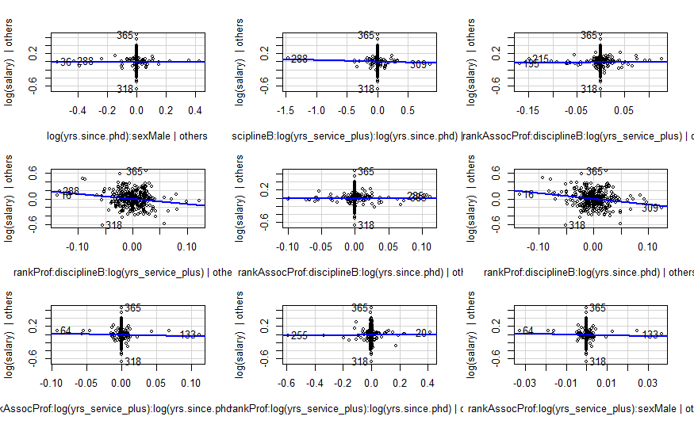

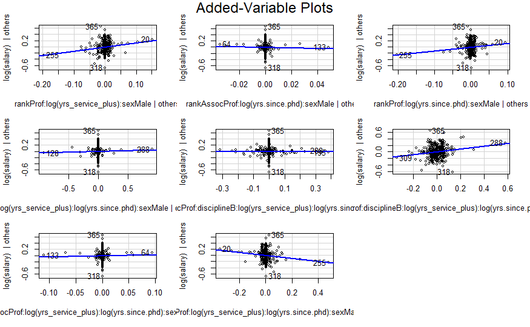

```r
avPlots(salarylog_mod, ask = FALSE)
```

```r
print(anova(salarylog_mod, salarylog))
```

```
Analysis of Variance Table

Model 1: log(salary) ~ rank + discipline + log(yrs_service_plus) + log(yrs.since.phd) +
    discipline * log(yrs_service_plus) + discipline * log(yrs.since.phd) +
    log(yrs_service_plus) * log(yrs.since.phd) + discipline *
    log(yrs_service_plus) * log(yrs.since.phd) + rank * discipline *
    log(yrs_service_plus) * log(yrs.since.phd) + rank * sex *
    log(yrs_service_plus) * log(yrs.since.phd)
Model 2: log(salary) ~ rank * discipline * sex * log(yrs_service_plus) *
    log(yrs.since.phd)
  Res.Df    RSS Df Sum of Sq      F Pr(>F)
1    361 11.048
2    349 10.714 12   0.33391 0.9064 0.5407
```

Our ANOVA tells us that the sub-model is fine to go with.

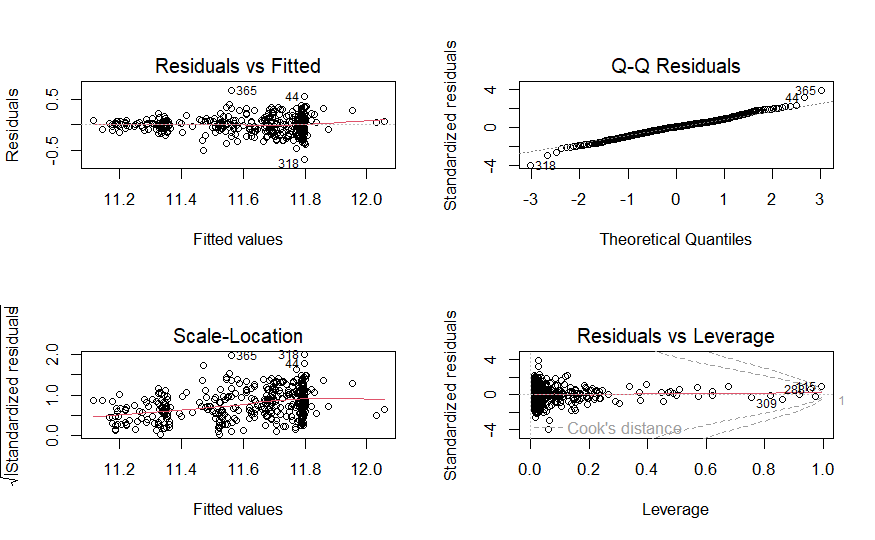

```r
par(mfrow = c(2,2))
plot(salarylog_mod)
```

```
                      Test stat Pr(>|Test stat|)
rank
discipline
log(yrs_service_plus)    1.5593           0.1198
log(yrs.since.phd)      -1.2105           0.2269
sex
Tukey test               1.4047           0.1601
```

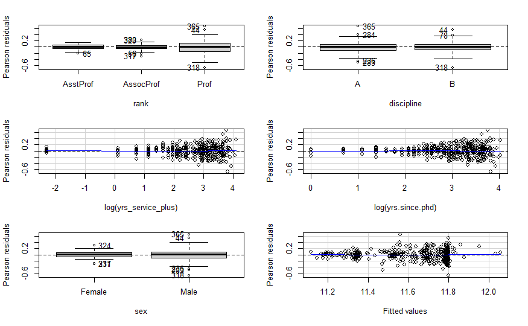

```r
residualPlots(salarylog_mod, ask = FALSE)
```

```r
print(resettest(salarylog_mod, power = 2:3, type = 'regressor'))
```

```
    RESET test

data:  salarylog_mod
RESET = 0.8014, df1 = 4, df2 = 357, p-value = 0.5249
```

```r
print(resettest(salarylog_mod, power = 2:3, type = 'fitted'))
```

```
    RESET test

data:  salarylog_mod
RESET = 1.1609, df1 = 2, df2 = 359, p-value = 0.3144
```

```r
ncvTest(salarylog_mod)
```

```
Non-constant Variance Score Test
Variance formula: ~ fitted.values
Chisquare = 39.41502, Df = 1, p = 3.4265e-10
```

```r
bptest(salarylog_mod)
```

```
    studentized Breusch-Pagan test

data:  salarylog_mod
BP = 68.518, df = 35, p-value = 0.0006016
```

```r
vif(salarylog_mod)
```

```
                                                                 GVIF Df GVIF^(1/(2*Df))
rank                                                     1.997584e+08  2      118.884784
discipline                                               1.390396e+02  1       11.791507
log(yrs_service_plus)                                    3.238506e+02  1       17.995850
log(yrs.since.phd)                                       2.534304e+02  1       15.919498
sex                                                      6.280881e+01  1        7.925201
discipline:log(yrs_service_plus)                         4.321077e+02  1       20.787200
discipline:log(yrs.since.phd)                            5.675133e+02  1       23.822537
log(yrs_service_plus):log(yrs.since.phd)                 2.240302e+03  1       47.331833
rank:discipline                                          4.077715e+06  2       44.937014
rank:log(yrs_service_plus)                               1.987140e+08  2      118.729082
rank:log(yrs.since.phd)                                  3.054887e+08  2      132.205276
rank:sex                                                 2.857881e+08  2      130.020264
log(yrs_service_plus):sex                                5.394063e+02  1       23.225123
log(yrs.since.phd):sex                                   4.124994e+02  1       20.310080
discipline:log(yrs_service_plus):log(yrs.since.phd)      1.967502e+03  1       44.356534
rank:discipline:log(yrs_service_plus)                    2.885673e+06  2       41.215615
rank:discipline:log(yrs.since.phd)                       6.018603e+06  2       49.530638
rank:log(yrs_service_plus):log(yrs.since.phd)            5.004775e+08  2      149.570564
rank:log(yrs_service_plus):sex                           2.889054e+08  2      130.373382
rank:log(yrs.since.phd):sex                              3.752166e+08  2      139.177973
log(yrs_service_plus):log(yrs.since.phd):sex             3.032644e+03  1       55.069449
rank:discipline:log(yrs_service_plus):log(yrs.since.phd) 5.356444e+06  2       48.108203
rank:log(yrs_service_plus):log(yrs.since.phd):sex        6.031494e+08  2      156.713433
```

```r
outlierTest(salarylog_mod)
```

|  | rstudent | unadjusted p-value | Bonferroni p |
| --- | --- | --- | --- |
| 318 | -4.090169 | 5.3221e-05 | 0.021129 |
| 365 | 3.973797 | 8.5475e-05 | 0.033934 |

```r
inf <- data.frame(
  hat = hatvalues(salarylog_mod),
  cooks = cooks.distance(salarylog_mod),
  rstandard = rstandard(salarylog_mod),
  rstudent = rstudent(salarylog_mod)
)

inlf <- infl[order(infl$cooks, decreasing = TRUE),]
print(head(infl))
```

|  | hat | cooks | rstudent | rstandard |
| --- | --- | --- | --- | --- |
| 115 | 0.9978153 | 6.0189734 | -0.7949160 | -0.7953355 |
| 335 | 0.9830351 | 3.7241196 | -1.7616848 | -1.7563996 |
| 53 | 0.9967328 | 2.5794004 | -0.6365156 | -0.6370588 |
| 36 | 0.9853913 | 0.5703164 | 0.6365156 | 0.6370588 |
| 219 | 0.7469258 | 0.2001650 | 1.8101386 | 1.8042633 |
| 91 | 0.9587776 | 0.1966538 | 0.6365156 | 0.6370588 |

```r
print(anova(salarylog_mod, salarylog))
```

```
Analysis of Variance Table

Model 1: log(salary) ~ rank + discipline + log(yrs_service_plus) + log(yrs.since.phd) +
    discipline * log(yrs_service_plus) + discipline * log(yrs.since.phd) +
    log(yrs_service_plus) * log(yrs.since.phd) + discipline *
    log(yrs_service_plus) * log(yrs.since.phd) + rank * discipline *
    log(yrs_service_plus) * log(yrs.since.phd) + rank * sex *
    log(yrs_service_plus) * log(yrs.since.phd)
Model 2: log(salary) ~ rank * discipline * sex * log(yrs_service_plus) *
    log(yrs.since.phd)
  Res.Df    RSS Df Sum of Sq      F Pr(>F)
1    361 11.048
2    349 10.714 12   0.33391 0.9064 0.5407
```

Finally, we see that this modified log-model performs almost just as well as the other submodels. We also see that sex is significant through its interactions with rank, years since phD, and years of service. When trying this same interactions in other models, it was still insignificant, only with a log response, does sex seem to be significant.

The next thing we will do is test how accurately each of the models predict. Once we get our predictions of how they explain outside data, using cross validation, we will also use the mean squared error to measure how far off our predictions we are. Since our model responses are on different scales, we will need to compare them all on the same response scale, so we will be using regular Salary in dollars to compare our models.

```r
formula_log <- salary~rank+discipline+log(yrs_service_plus)+log(yrs.since.phd)+discipline*log(yrs_service_plus)+discipline*log(yrs.since.phd)+log(yrs_service_plus)*log(yrs.since.phd)+discipline*log(yrs_service_plus)*log(yrs.since.phd)+rank*discipline*log(yrs_service_plus)*log(yrs.since.phd)+rank*sex*log(yrs_service_plus)*log(yrs.since.phd)



formula_sqrt <- salary~rank+discipline+sqrt(yrs.service)+sqrt(yrs.since.phd)+discipline*sqrt(yrs.service)+discipline*sqrt(yrs.since.phd)+sqrt(yrs.service)*sqrt(yrs.since.phd)+discipline*sqrt(yrs.service)*sqrt(yrs.since.phd)+rank*discipline*sqrt(yrs.service)*sqrt(yrs.since.phd)




formula_pwr <- salary~rank+discipline+I(yrs_service_plus^0.52)+I(yrs.since.phd^0.59)+discipline*I(yrs_service_plus^0.52)+discipline*I(yrs.since.phd^0.59)+discipline*I(yrs_service_plus^0.52)*I(yrs.since.phd^0.59)+rank*discipline*I(yrs_service_plus^0.52)*I(yrs.since.phd^0.59)


split_obj <- initial_split(Salaries, prop = .80)
salaries_train <- training(split_obj)
salaries_test <- testing(split_obj)

enet_pipe <- linear_reg(penalty = tune(), mixture = tune()) %>% set_engine('glmnet')


log_flow <- workflow() %>% add_model(enet_pipe) %>% add_formula(formula_log)

sqrt_flow <- workflow() %>% add_model(enet_pipe) %>% add_formula(formula_sqrt)

pwr_flow <- workflow() %>% add_model(enet_pipe) %>% add_formula(formula_pwr)

folds <- vfold_cv(salaries_train, v = 10)

mset <- metric_set(rsq, mae, rmse)

grid <- grid_latin_hypercube(
  penalty(range = c(-6, 1)),
  mixture(range = c(0, 1)),
  size = 50
)

ctrl <- control_grid(save_pred = TRUE)

log_full <- tune_grid(
  log_flow, resamples = folds, grid = grid,
  metrics = mset, control = ctrl
)

sqrt_full <- tune_grid(
  sqrt_flow, resamples = folds, grid = grid,
  metrics = mset, control = ctrl
)

pwr_full <- tune_grid(
  pwr_flow, resamples = folds, grid = grid,
  metrics = mset, control = ctrl
)


best_log <- select_best(log_full, metric = 'rsq')
best_sqrt <- select_best(sqrt_full, metric = 'rsq')
best_pwr <- select_best(pwr_full, metric = 'rsq')

print(best_log)
```

| penalty | mixture | .config |
| --- | --- | --- |
| 1.502548 | 0.929749 | pre0_mod45_post0 |

```r
print(best_sqrt)
```

| penalty | mixture | .config |
| --- | --- | --- |
| 0.001304902 | 0.713053 | pre0_mod23_post0 |

```r
print(best_pwr)
```

| penalty | mixture | .config |
| --- | --- | --- |
| 0.0005476123 | 0.894894 | pre0_mod20_post0 |

```r
print(collect_metrics(log_full)[collect_metrics(log_full)$penalty == best_log$penalty,])
```

| penalty | mixture | .metric | .estimator | mean | n | std_err | .config |
| --- | --- | --- | --- | --- | --- | --- | --- |
| 1.502548 | 0.929749 | mae | standard | 1.586564e+04 | 10 | 8.026746e+02 | pre0_mod45_post0 |
| 1.502548 | 0.929749 | rmse | standard | 2.136098e+04 | 10 | 1.045819e+03 | pre0_mod45_post0 |
| 1.502548 | 0.929749 | rsq | standard | 4.757971e-01 | 10 | 3.333906e-02 | pre0_mod45_post0 |

```r
print(collect_metrics(sqrt_full)[collect_metrics(sqrt_full)$penalty == best_sqrt$penalty,])
```

| penalty | mixture | .metric | .estimator | mean | n | std_err | .config |
| --- | --- | --- | --- | --- | --- | --- | --- |
| 0.001304902 | 0.713053 | mae | standard | 1.552686e+04 | 10 | 6.914513e+02 | pre0_mod23_post0 |
| 0.001304902 | 0.713053 | rmse | standard | 2.101444e+04 | 10 | 1.048257e+03 | pre0_mod23_post0 |
| 0.001304902 | 0.713053 | rsq | standard | 4.980812e-01 | 10 | 2.746781e-02 | pre0_mod23_post0 |

```r
print(collect_metrics(pwr_full)[collect_metrics(pwr_full)$penalty == best_pwr$penalty,])
```

| penalty | mixture | .metric | .estimator | mean | n | std_err | .config |
| --- | --- | --- | --- | --- | --- | --- | --- |
| 0.0005476123 | 0.894894 | mae | standard | 1.546880e+04 | 10 | 6.815184e+02 | pre0_mod20_post0 |
| 0.0005476123 | 0.894894 | rmse | standard | 2.096931e+04 | 10 | 1.038459e+03 | pre0_mod20_post0 |
| 0.0005476123 | 0.894894 | rsq | standard | 5.009203e-01 | 10 | 2.665775e-02 | pre0_mod20_post0 |

```r
eps <- 1e-12

inv_log <- function(yt){
  exp(yt)
}

inv_inv_sqrt <- function(yt){
  yt <- pmax(yt, eps)
  (1 / yt)^2
}

inv_neg_quarter <- function(yt){
  yt <- pmax(yt, eps)
  1 / (yt^4)
}

full_finalize_log <- finalize_workflow(log_flow, best_log) %>% fit(salaries_train)
full_finalize_sqrt <- finalize_workflow(sqrt_flow, best_sqrt) %>% fit(salaries_train)
full_finalize_pwr <- finalize_workflow(pwr_flow, best_pwr) %>% fit(salaries_train)

pred_log <- predict(full_finalize_log, salaries_test) %>% bind_cols(salaries_test %>% select(salary))


pred_sqrt <- predict(full_finalize_sqrt, salaries_test) %>% bind_cols(salaries_test %>% select(salary))


pred_pwr <- predict(full_finalize_pwr, salaries_test) %>% bind_cols(salaries_test %>% select(salary))


print(metrics(pred_log, truth = salary, estimate = .pred))
```

| .metric | .estimator | .estimate |
| --- | --- | --- |
| rmse | standard | 2.406319e+04 |
| rsq | standard | 4.615602e-01 |
| mae | standard | 1.820087e+04 |

```r
print(metrics(pred_sqrt, truth = salary, estimate = .pred))
```

| .metric | .estimator | .estimate |
| --- | --- | --- |
| rmse | standard | 2.391155e+04 |
| rsq | standard | 4.663482e-01 |
| mae | standard | 1.812193e+04 |

```r
print(metrics(pred_pwr, truth = salary, estimate = .pred))
```

| .metric | .estimator | .estimate |
| --- | --- | --- |
| rmse | standard | 23901.964696 |
| rsq | standard | 0.467143 |
| mae | standard | 18100.840552 |

```r
tol <- 1e-6

coef_log <- full_finalize_log %>% extract_fit_parsnip %>% tidy() %>% filter(term != '(Intercept)')

chosen_log <- coef_log %>% filter(abs(estimate) > tol)
neglected_log <- coef_log %>% filter(abs(estimate) <= tol)

print(chosen_log)
```

| term | estimate | penalty |
| --- | --- | --- |
| rankAssocProf | 2.630392e+04 | 1.502548 |
| rankProf | -1.601312e+05 | 1.502548 |
| disciplineB | 1.866683e+04 | 1.502548 |
| log(yrs_service_plus) | -2.243428e+03 | 1.502548 |
| log(yrs.since.phd) | 3.267408e+03 | 1.502548 |
| sexMale | -6.463891e+03 | 1.502548 |
| disciplineB:log(yrs_service_plus) | 1.708595e+03 | 1.502548 |
| disciplineB:log(yrs.since.phd) | -7.362598e+03 | 1.502548 |
| log(yrs_service_plus):log(yrs.since.phd) | 3.239036e+00 | 1.502548 |
| rankAssocProf:disciplineB | -5.314499e+04 | 1.502548 |

[output cut: 23 more lines]

```r
print(neglected_log)
```

| term | estimate | penalty |
| --- | --- | --- |
| rankAssocProf:log(yrs.since.phd) | 0 | 1.502548 |
| rankAssocProf:sexMale | 0 | 1.502548 |

```r
coef_sqrt <- full_finalize_sqrt %>% extract_fit_parsnip %>% tidy() %>% filter(term != '(Intercept)')

chosen_sqrt <- coef_sqrt %>% filter(abs(estimate) > tol)
neglected_sqrt <- coef_sqrt %>% filter(abs(estimate) <= tol)

print(chosen_sqrt)
```

| term | estimate | penalty |
| --- | --- | --- |
| rankAssocProf | 37939.982 | 0.001304902 |
| rankProf | -96177.198 | 0.001304902 |
| disciplineB | 30067.171 | 0.001304902 |
| sqrt(yrs.service) | 1669.098 | 0.001304902 |
| sqrt(yrs.since.phd) | 11378.520 | 0.001304902 |
| disciplineB:sqrt(yrs.service) | -2125.004 | 0.001304902 |
| disciplineB:sqrt(yrs.since.phd) | -15158.624 | 0.001304902 |
| sqrt(yrs.service):sqrt(yrs.since.phd) | -2982.376 | 0.001304902 |
| rankAssocProf:disciplineB | -18331.216 | 0.001304902 |
| rankProf:disciplineB | 159393.779 | 0.001304902 |

[output cut: 13 more lines]

```r
print(neglected_sqrt)
```

| term | estimate | penalty |
| --- | --- | --- |

```r
coef_pwr <- full_finalize_pwr %>% extract_fit_parsnip %>% tidy() %>% filter(term != '(Intercept)')

chosen_pwr <- coef_pwr %>% filter(abs(estimate) > tol)
neglected_pwr <- coef_pwr %>% filter(abs(estimate) <= tol)

print(chosen_pwr)
```

| term | estimate | penalty |
| --- | --- | --- |
| rankAssocProf | 28023.2931 | 0.0005476123 |
| rankProf | -68911.5612 | 0.0005476123 |
| disciplineB | 22102.1086 | 0.0005476123 |
| I(yrs_service_plus^0.52) | 161.6765 | 0.0005476123 |
| I(yrs.since.phd^0.59) | 6405.9049 | 0.0005476123 |
| disciplineB:I(yrs.since.phd^0.59) | -9784.7018 | 0.0005476123 |
| I(yrs_service_plus^0.52):I(yrs.since.phd^0.59) | -1470.7926 | 0.0005476123 |
| rankAssocProf:disciplineB | -4083.1836 | 0.0005476123 |
| rankProf:disciplineB | 128620.2291 | 0.0005476123 |
| rankAssocProf:I(yrs_service_plus^0.52) | -12380.6185 | 0.0005476123 |

[output cut: 12 more lines]

```r
print(neglected_pwr)
```

| term | estimate | penalty |
| --- | --- | --- |
| disciplineB:I(yrs_service_plus^0.52) | 0 | 0.0005476123 |

Here, we see that the power-model seems to predict the best all around the board. Both when we do 10-fold and when we do a hold out. We see that not only does the power-model has the lowest Mean Squared Error, it also consistently has the highest R-squared, so, it seems to explain more of the variation of the data. However, in general, for prediction we would probably rather use something like a decision tree or gradient boosting model for more accurate predictions.